# Data Analysis for Business, Economics and Policy

Case studies

Fernando Millan Villalobos

July 2021

# 1 Notes

This report was generated on 2021-11-09 14:48:55. R version: 4.1.2 on x86_64-pc-linux-gnu. For this report, CRAN packages as of 2021-11-01 were used.

## 1.4 Data description of output files

[output not shown]

# 2 Set up

```
## [1] "package package:datasets detached"
```

```
## [1] "package package:rstudioapi detached"
## [1] "package package:knitr detached"
```

## 2.1 Define packages

```r
# from https://mran.revolutionanalytics.com/web/packages/\
# checkpoint/vignettes/using-checkpoint-with-knitr.html
# if you don't need a package, remove it from here (commenting not sufficient)
# tidyverse: see https://blog.rstudio.org/2016/09/15/tidyverse-1-0-0/
# cat("
# library(rstudioapi)
# library(tidyverse, warn.conflicts = FALSE) # ggplot2, dplyr, tidyr, readr, purrr, tibble, magrittr, readxl
# library(scales) # scales for ggplot2
# library(jsonlite) # json
# library(desc)
# library(lintr)",
#   file = "manifest.R"
# )
```

```r
# from https://mran.revolutionanalytics.com/web/packages/\
# checkpoint/vignettes/using-checkpoint-with-knitr.html
# if you don't need a package, remove it from here (commenting not sufficient)
# tidyverse: see https://blog.rstudio.org/2016/09/15/tidyverse-1-0-0/
cat("
library(rstudioapi)
library(tidyverse, warn.conflicts = FALSE) # ggplot2, dplyr, tidyr, readr, purrr, tibble, magrittr, readxl
library(scales) # scales for ggplot2
library(jsonlite) # json
library(lintr) # code linting
library(sf)
library(rmarkdown)
library(data.table)
library(cowplot) # theme
library(extrafont)
library(waldo) # compare
library(psych) # some useful funs
library(ggrepel)
library(skimr)
library(haven)
library(Hmisc)
library(desc)
library(reshape2)
library(pastecs)
library(patchwork)
library(xtable)
library(reticulate)
library(binsreg)
library(boot)
library(modelsummary)
library(viridis)
library(grid)
library(janitor)", # names
  file = "manifest.R"
)
# library(sf)
```

## 2.2 Install packages

```r
# if checkpoint is not yet installed, install it (for people using this
# system for the first time)
if (!require(checkpoint)) {
  if (!require(devtools)) {
    install.packages("devtools", repos = "http://cran.us.r-project.org")
    require(devtools)
  }
  devtools::install_github("RevolutionAnalytics/checkpoint",
    ref = "v0.3.2", # could be adapted later,
    # as of now (beginning of July 2017
    # this is the current release on CRAN)
    repos = "http://cran.us.r-project.org"
  )
  require(checkpoint)
}
# nolint start
if (!dir.exists("~/.checkpoint")) {
  dir.create("~/.checkpoint")
}
# nolint end
# install packages for the specified CRAN snapshot date
checkpoint(
  snapshot_date = package_date,
  project = path_to_wd,
  verbose = T,
  scanForPackages = T,
  use.knitr = F,
  R.version = r_version
)
rm(package_date)
```

## 2.3 Load packages

```r
source("manifest.R")
unlink("manifest.R")
```

## 2.4 Load additional scripts

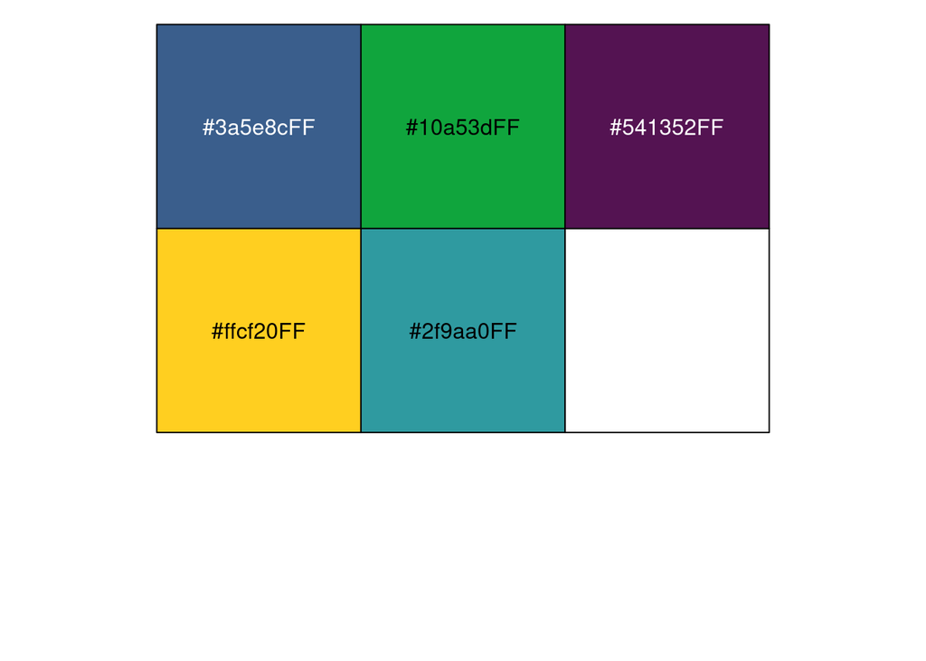

```r
# if you want to outsource logic to other script files, see README for
# further information
# Load all visualizations functions as separate scripts
knitr::read_chunk("scripts/dviz.supp.R")
source("scripts/dviz.supp.R")
knitr::read_chunk("scripts/themes.R")
source("scripts/themes.R")
knitr::read_chunk("scripts/plot_grid.R")
source("scripts/plot_grid.R")
knitr::read_chunk("scripts/align_legend.R")
source("scripts/align_legend.R")
knitr::read_chunk("scripts/label_log10.R")
source("scripts/label_log10.R")
knitr::read_chunk("scripts/outliers.R")
source("scripts/outliers.R")
knitr::read_chunk("scripts/theme_bg.R")
source("scripts/theme_bg.R")
```

# 3 CHAPTER 02: Preparing Data for Analysis

## 3.1 Entity Resolution: Duplicates, Ambiguous Identification, and Non-entity Rows

One potential issue is having **duplicate observations** in the data table. In the simplest case, duplicates are perfect: the value of all variables is the same. In such cases we have to delete duplicates and leave one data row for each observation only.

A related, but conceptually different issue is to have **ambiguous identification**: the same entity having different IDs across different tables. The task here is to make sure that each entity has the same ID across data tables. That is necessary to link them properly. Entities are frequently identified by names. Unfortunately, though, names may cause issues for two main reasons: they are not unique, and different data tables may have different versions of the same name. This task is called **disambiguation**: making identification of entities not ambiguous.

Yet another issue is having non-entity observations: rows that do not belong to an entity we want in the data table. Before any meaningful analysis can be done, we need to erase such rows from the data table. The important message is this: *assigning unique IDs is important and using numerical ID variables is good practice*.

## 3.2 Managing Missing Values

Having missing values for some variables is a frequent problem. There are two different main approaches: First, we can work with observations that have non-missing values for all variables used in the analysis. This is the most natural and most common approach. One version of this approach is to work with observations that make up a well-defined subsample, in which the missing data problem is a lot less severe. The second option is filling in some value for the missing values, such as the average value. This is called **imputation**. When missing values are replaced with some other values, it is good practice to create a binary variable that indicates that the original value was missing. Such a variable is called a **flag**.

When possible, focus on more fully filled variables. Imputation for qualitative variables should be done differently. We should add an additional category for missing values. For ordinal variables, we may also impute the median category and add a new variable denoting that the original value was missing.

## 3.3 Organizing Data Tables for a Project

It is good practice to organize and store the data at three levels:

- Raw data tables
- Clean and tidy data tables
- Workfile for analysis

**Raw data** may come in a single or in multiple files. It should be stored in the original format before anything is done to it. The next step is producing **clean** and **tidy** data from raw data. Often tidy data means multiple data tables. We should always create different data tables for data with different kinds of observations. The last of the three levels is the one on which the analysis is to be done: the **workfile**.

Project overview:

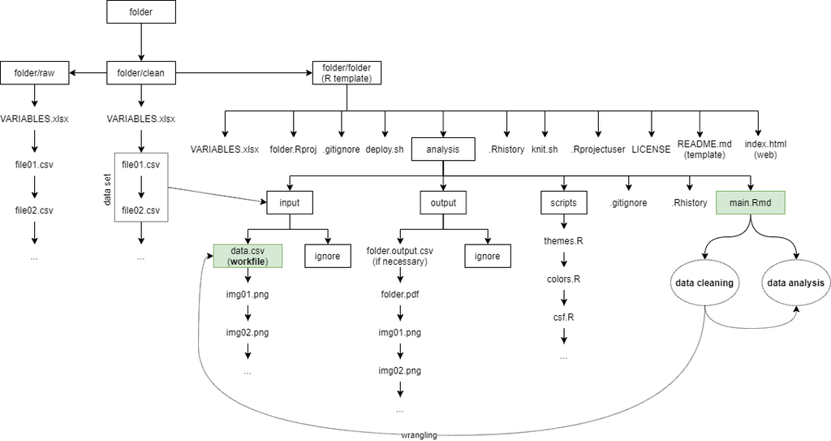

Project Overview

```r
# load hotels_raw
hotels_raw <- read_csv("input/hotelbookingdata-vienna.csv")
# load hotels_clean
hotels_clean <- read_csv("input/hotels-vienna.csv")

# transform values of some variables (through splitting) into valid values
hotels_raw <- hotels_raw |>
  tidyr::separate(center1distance, c("distance", NA), sep = " ") |>
  tidyr::separate(center2distance, c("distance_alter", NA), sep = " ") |>
  tidyr::separate(accommodationtype, c(NA, "accommodation_type"), sep = "@") |>
  tidyr::separate(price_night, c(NA, NA, "nnight", NA), sep = " ") |>
  tidyr::separate(guestreviewsrating, c("rating", NA), sep = " ")
head(hotels_raw)
```

```
## # A tibble: 6 × 24
##   addresscountryname city_actual rating_reviewcount distance center1label
##   <chr>              <chr>                    <dbl> <chr>    <chr>
## 1 Austria            Vienna                      36 2.7      City centre
## 2 Austria            Vienna                     189 1.7      City centre
## 3 Austria            Vienna                      53 1.4      City centre
## 4 Austria            Vienna                      55 1.7      City centre
## 5 Austria            Vienna                      33 1.2      City centre
## 6 Austria            Vienna                      25 0.9      City centre
## # … with 19 more variables: distance_alter <chr>, center2label <chr>,
## #   neighbourhood <chr>, price <dbl>, nnight <chr>, s_city <chr>,
## #   starrating <dbl>, rating2_ta <dbl>, rating2_ta_reviewcount <dbl>,
## #   accommodation_type <chr>, rating <chr>, scarce_room <dbl>, hotel_id <dbl>,
## #   offer <dbl>, offer_cat <chr>, year <dbl>, month <dbl>, weekend <dbl>,
## #   holiday <dbl>
```

```r
# check: frequency table of all values incl. missing values
tab_rating <- hotels_raw |>
  dplyr::group_by(rating) |>
  dplyr::summarise(n = n()) |>
  dplyr::mutate(
    percent = round((n / sum(n)), 3),
    cumpercent = round(cumsum(freq = n / sum(n)), 3)
  )

tab_rating_reviewcount <- hotels_raw |>
  dplyr::group_by(rating_reviewcount) |>
  dplyr::summarise(n = n()) |>
  dplyr::mutate(
    percent = round((n / sum(n)), 3),
    cumpercent = round(cumsum(freq = n / sum(n)), 3)
  )

hotels_raw <- hotels_raw |>
  dplyr::mutate(rating_count = as.numeric(rating_reviewcount))

Hmisc::describe(hotels_raw$rating_count)
```

```
## hotels_raw$rating_count
##        n  missing distinct     Info     Mean      Gmd      .05      .10
##      395       35      224        1    155.3    179.9      2.0      6.0
##      .25      .50      .75      .90      .95
##     26.5     84.0    203.0    381.2    527.9
##
## lowest :    1    2    3    4    5, highest:  910  923  985 1122 1541
```

```r
# rename variables
hotels_raw <- hotels_raw |>
  dplyr::rename(
    ratingta = rating2_ta,
    ratingta_count = rating2_ta_reviewcount,
    country = addresscountryname,
    city = s_city, stars = starrating
  )


# check: key variables
tab_stars <- hotels_raw |>
  dplyr::group_by(stars) |>
  dplyr::summarise(n = n()) |>
  dplyr::mutate(
    percent = round((n / sum(n)), 3),
    cumpercent = round(cumsum(freq = n / sum(n)), 3)
  )

tab_rating <- hotels_raw |>
  dplyr::group_by(rating) |>
  dplyr::summarise(n = n()) |>
  dplyr::mutate(
    percent = round((n / sum(n)), 3),
    cumpercent = round(cumsum(freq = n / sum(n)), 3)
  )

# look for perfect duplicates
hotels_raw <- hotels_raw |>
  dplyr::arrange(hotel_id)

# filtering duplicates rows by IDs and selecting key variables to check
hotels_raw |>
  dplyr::group_by(hotel_id) |>
  dplyr::filter(n() > 1) |>
  dplyr::select(c(hotel_id, accommodation_type, price, distance, stars, rating, rating_count))
```

```
## # A tibble: 4 × 7
## # Groups:   hotel_id [2]
##   hotel_id accommodation_type price distance stars rating rating_count
##      <dbl> <chr>              <dbl> <chr>    <dbl> <chr>         <dbl>
## 1    22050 Hotel                242 0.0          4 4.8             404
## 2    22050 Hotel                242 0.0          4 4.8             404
## 3    22185 Hotel                 84 0.8          3 2.2               3
## 4    22185 Hotel                 84 0.8          3 2.2               3
```

```r
# getting rid of all duplicates (perfect duplicates)
hotels_raw <- hotels_raw |>
  dplyr::distinct()

# handling missing values in text
# checking NAs values
summary(hotels_raw)
```

```
##    country          city_actual        rating_reviewcount   distance
##  Length:428         Length:428         Min.   :   1       Length:428
##  Class :character   Class :character   1st Qu.:  27       Class :character
##  Mode  :character   Mode  :character   Median :  84       Mode  :character
##                                        Mean   : 155
##                                        3rd Qu.: 203
##                                        Max.   :1541
##                                        NA's   :35
##  center1label       distance_alter     center2label       neighbourhood
##  Length:428         Length:428         Length:428         Length:428
##  Class :character   Class :character   Class :character   Class :character
##  Mode  :character   Mode  :character   Mode  :character   Mode  :character
##
##
##
##
##      price           nnight              city               stars
##  Min.   :  27.0   Length:428         Length:428         Min.   :1.000
##  1st Qu.:  83.0   Class :character   Class :character   1st Qu.:3.000
##  Median : 109.5   Mode  :character   Mode  :character   Median :3.500
##  Mean   : 131.4                                         Mean   :3.435
##  3rd Qu.: 146.0                                         3rd Qu.:4.000
##  Max.   :1012.0                                         Max.   :5.000
##
##     ratingta     ratingta_count   accommodation_type    rating
##  Min.   :2.000   Min.   :   2.0   Length:428         Length:428
##  1st Qu.:3.500   1st Qu.: 129.0   Class :character   Class :character
##  Median :4.000   Median : 335.0   Mode  :character   Mode  :character
##  Mean   :3.991   Mean   : 556.5
##  3rd Qu.:4.500   3rd Qu.: 811.0
##  Max.   :5.000   Max.   :3171.0
##  NA's   :103     NA's   :103
##   scarce_room        hotel_id         offer         offer_cat
##  Min.   :0.0000   Min.   :21894   Min.   :0.0000   Length:428
##  1st Qu.:0.0000   1st Qu.:22028   1st Qu.:0.0000   Class :character
##  Median :1.0000   Median :22156   Median :1.0000   Mode  :character
##  Mean   :0.5981   Mean   :22154   Mean   :0.6799
##  3rd Qu.:1.0000   3rd Qu.:22279   3rd Qu.:1.0000
##  Max.   :1.0000   Max.   :22409   Max.   :1.0000
##
##       year          month       weekend     holiday   rating_count
##  Min.   :2017   Min.   :11   Min.   :0   Min.   :0   Min.   :   1
##  1st Qu.:2017   1st Qu.:11   1st Qu.:0   1st Qu.:0   1st Qu.:  27
##  Median :2017   Median :11   Median :0   Median :0   Median :  84
##  Mean   :2017   Mean   :11   Mean   :0   Mean   :0   Mean   : 155
##  3rd Qu.:2017   3rd Qu.:11   3rd Qu.:0   3rd Qu.:0   3rd Qu.: 203
##  Max.   :2017   Max.   :11   Max.   :0   Max.   :0   Max.   :1541
##                                                      NA's   :35
```

```r
# making a summary of the missing values
summary_wms <- t(stat.desc(hotels_raw))
summary_wms
```

```
##                    nbr.val nbr.null nbr.na   min   max range     sum  median
## country                 NA       NA     NA    NA    NA    NA      NA      NA
## city_actual             NA       NA     NA    NA    NA    NA      NA      NA
## rating_reviewcount     393        0     35     1  1541  1540   60934    84.0
## distance                NA       NA     NA    NA    NA    NA      NA      NA
## center1label            NA       NA     NA    NA    NA    NA      NA      NA
## distance_alter          NA       NA     NA    NA    NA    NA      NA      NA
## center2label            NA       NA     NA    NA    NA    NA      NA      NA
## neighbourhood           NA       NA     NA    NA    NA    NA      NA      NA
## price                  428        0      0    27  1012   985   56225   109.5
## nnight                  NA       NA     NA    NA    NA    NA      NA      NA
## city                    NA       NA     NA    NA    NA    NA      NA      NA
## stars                  428        0      0     1     5     4    1470     3.5
## ratingta               325        0    103     2     5     3    1297     4.0
## ratingta_count         325        0    103     2  3171  3169  180868   335.0
## accommodation_type      NA       NA     NA    NA    NA    NA      NA      NA
## rating                  NA       NA     NA    NA    NA    NA      NA      NA
## scarce_room            428      172      0     0     1     1     256     1.0
## hotel_id               428        0      0 21894 22409   515 9481699 22155.5
## offer                  428      137      0     0     1     1     291     1.0
## offer_cat               NA       NA     NA    NA    NA    NA      NA      NA
## year                   428        0      0  2017  2017     0  863276  2017.0
## month                  428        0      0    11    11     0    4708    11.0
## weekend                428      428      0     0     0     0       0     0.0
## holiday                428      428      0     0     0     0       0     0.0
## rating_count           393        0     35     1  1541  1540   60934    84.0
##                             mean     SE.mean     CI.mean            var
## country                       NA          NA          NA             NA
## city_actual                   NA          NA          NA             NA
## rating_reviewcount   155.0483461  9.64564363 18.96366437  36564.1073506
## distance                      NA          NA          NA             NA
## center1label                  NA          NA          NA             NA
## distance_alter                NA          NA          NA             NA
## center2label                  NA          NA          NA             NA
## neighbourhood                 NA          NA          NA             NA
## price                131.3668224  4.42671274  8.70085957   8386.9962737
## nnight                        NA          NA          NA             NA
## city                          NA          NA          NA             NA
## stars                  3.4345794  0.03732945  0.07337234      0.5964127
## ratingta               3.9907692  0.02677193  0.05266875      0.2329392
```

[output cut: 23 more lines]

```
## city                        NA          NA
## stars                0.7722776 0.224853616
## ratingta             0.4826378 0.120938533
## ratingta_count     586.8745822 1.054549391
## accommodation_type          NA          NA
## rating                      NA          NA
## scarce_room          0.4908495 0.820639067
## hotel_id           146.8584767 0.006629131
## offer                0.4670582 0.686944635
## offer_cat                   NA          NA
## year                 0.0000000 0.000000000
## month                0.0000000 0.000000000
## weekend              0.0000000         NaN
## holiday              0.0000000         NaN
## rating_count       191.2174347 1.233276198
```

```r
# creating a flag variable for missing values
hotels_raw <- hotels_raw |>
  dplyr::mutate(misrating = ifelse(is.na(rating), 1, 0))

# counting all missing values
table(hotels_raw$misrating)
```

```
##
##   0   1
## 393  35
```

```r
# looking missing values number per accomodation type
addmargins(table(hotels_raw$accommodation_type, hotels_raw$misrating))
```

```
##
##                         0   1 Sum
##   Apart-hotel           4   0   4
##   Apartment            92  32 124
##   Bed and breakfast     4   0   4
##   Guest House           7   1   8
##   Hostel                6   0   6
##   Hotel               263   1 264
##   Pension              16   0  16
##   Vacation home Condo   1   1   2
##   Sum                 393  35 428
```

```r
# looking at the relation between missing values and price (mean)
hotels_raw |>
  dplyr::group_by(accommodation_type, misrating) |>
  dplyr::summarise(mean(price))
```

```
## # A tibble: 12 × 3
## # Groups:   accommodation_type [8]
##    accommodation_type  misrating `mean(price)`
##    <chr>                   <dbl>         <dbl>
##  1 Apart-hotel                 0         121.
##  2 Apartment                   0         136.
##  3 Apartment                   1         179.
##  4 Bed and breakfast           0         118.
##  5 Guest House                 0          71
##  6 Guest House                 1         103
##  7 Hostel                      0          53.7
##  8 Hotel                       0         130.
##  9 Hotel                       1         106
## 10 Pension                     0          96.1
## 11 Vacation home Condo         0         107
## 12 Vacation home Condo         1         116
```

```r
# spotting the exceptional case for "Hotels"
hotels_raw |>
  dplyr::filter((misrating == 1) & (accommodation_type == "Hotel")) |>
  dplyr::select(hotel_id, accommodation_type, price, distance, stars, rating, rating_count) |>
  dplyr::slice(1)
```

```
## # A tibble: 1 × 7
##   hotel_id accommodation_type price distance stars rating rating_count
##      <dbl> <chr>              <dbl> <chr>    <dbl> <chr>         <dbl>
## 1    21916 Hotel                106 0.7        2.5 <NA>             NA
```

## 3.4 Finding the Most Successful Managers

```r
# load data
games <- read_csv("input/epl_games.csv")
team_games <- read_csv("input/epl-teams-games.csv")
managers <- read_csv("input/football_managers.csv")
merged <- read_csv("input/football_managers_workfile.csv")

dplyr::glimpse(games)
```

```
## Rows: 4,180
## Columns: 9
## $ div         <chr> "E0", "E0", "E0", "E0", "E0", "E0", "E0", "E0", "E0", "E0"…
## $ season      <dbl> 2008, 2008, 2008, 2008, 2008, 2008, 2008, 2008, 2008, 2008…
## $ date        <chr> "16aug2008", "16aug2008", "16aug2008", "16aug2008", "16aug…
## $ team_home   <chr> "Arsenal", "West Ham", "Middlesbrough", "Everton", "Bolton…
## $ team_away   <chr> "West Brom", "Wigan", "Tottenham", "Blackburn", "Stoke", "…
## $ points_home <dbl> 3, 3, 3, 0, 3, 0, 3, 3, 1, 3, 3, 3, 1, 0, 3, 0, 3, 0, 3, 0…
## $ points_away <dbl> 0, 0, 0, 3, 0, 3, 0, 0, 1, 0, 0, 0, 1, 3, 0, 3, 0, 3, 0, 3…
## $ goals_home  <dbl> 1, 2, 2, 2, 3, 0, 2, 4, 1, 4, 2, 3, 1, 1, 1, 1, 1, 0, 3, 0…
## $ goals_away  <dbl> 0, 1, 1, 3, 1, 1, 1, 0, 1, 2, 1, 2, 1, 2, 0, 2, 0, 1, 0, 1…
```

```r
dplyr::glimpse(team_games)
```

```
## Rows: 8,360
## Columns: 13
## $ div             <chr> "E0", "E0", "E0", "E0", "E0", "E0", "E0", "E0", "E0", …
## $ season          <dbl> 2008, 2008, 2008, 2008, 2008, 2008, 2008, 2008, 2008, …
## $ date            <chr> "16aug2008", "23aug2008", "30aug2008", "13sep2008", "2…
## $ team            <chr> "Arsenal", "Arsenal", "Arsenal", "Arsenal", "Arsenal",…
## $ gameno          <dbl> 1, 2, 3, 4, 5, 6, 7, 8, 9, 10, 11, 12, 13, 14, 15, 16,…
## $ home            <dbl> 1, 0, 1, 0, 0, 1, 0, 1, 0, 1, 0, 1, 1, 0, 0, 1, 0, 1, …
## $ points          <dbl> 3, 0, 3, 3, 3, 0, 1, 3, 3, 1, 0, 3, 0, 0, 3, 3, 1, 1, …
## $ goals           <dbl> 1, 0, 3, 4, 3, 1, 1, 3, 2, 4, 1, 2, 0, 0, 2, 1, 1, 1, …
## $ team_opponent   <chr> "West Brom", "Fulham", "Newcastle", "Blackburn", "Bolt…
## $ points_opponent <dbl> 0, 3, 0, 0, 0, 3, 1, 0, 0, 1, 3, 0, 3, 3, 0, 0, 1, 1, …
## $ goals_opponent  <dbl> 0, 1, 0, 0, 1, 2, 1, 1, 0, 4, 2, 1, 2, 3, 1, 0, 1, 1, …
## $ hometeam_uid    <dbl> 1, 14, 1, 4, 6, 1, 29, 1, 34, 1, 28, 1, 1, 19, 11, 1, …
## $ awayteam_uid    <dbl> 33, 1, 22, 1, 1, 16, 1, 13, 1, 31, 1, 20, 2, 1, 1, 35,…
```

```r
dplyr::glimpse(managers)
```

```
## Rows: 395
## Columns: 9
## $ manager_id    <chr> "George Graham", "Stewart Houston", "Bruce Rioch", "Stew…
## $ manager_name  <chr> "George Graham", "Stewart Houston", "Bruce Rioch", "Stew…
## $ club          <chr> "Arsenal", "Arsenal", "Arsenal", "Arsenal", "Arsenal", "…
## $ caretaker     <dbl> 0, 1, 0, 1, 1, 0, 0, 0, 0, 0, 1, 1, 0, 0, 0, 1, 0, 1, 0,…
## $ date_from     <chr> "14may1986", "22feb1995", "08jun1995", "12aug1996", "13s…
## $ date_until    <chr> "21feb1995", "08jun1995", "12aug1996", "13sep1996", "30s…
## $ nat           <chr> "Scotland", "Scotland", "Scotland", "Scotland", "Norther…
## $ league        <chr> "EPL", "EPL", "EPL", "EPL", "EPL", "EPL", "EPL", "EPL", …
## $ flag_inoffice <dbl> 0, 0, 0, 0, 0, 0, 1, 0, 0, 0, 0, 0, 0, 0, 0, 0, 0, 0, 0,…
```

```r
dplyr::glimpse(merged)
```

```
## Rows: 8,360
## Columns: 19
## $ div               <chr> "E0", "E0", "E0", "E0", "E0", "E0", "E0", "E0", "E0"…
## $ season            <dbl> 2008, 2008, 2008, 2008, 2008, 2008, 2008, 2008, 2008…
## $ date              <date> 2009-04-04, 2009-02-08, 2009-04-21, 2008-10-04, 200…
## $ team              <chr> "Arsenal", "Arsenal", "Arsenal", "Arsenal", "Arsenal…
## $ gameno            <dbl> 31, 25, 33, 7, 20, 2, 28, 35, 19, 18, 26, 14, 23, 3,…
## $ home              <dbl> 1, 0, 0, 0, 1, 0, 0, 0, 0, 1, 1, 0, 0, 1, 0, 0, 0, 1…
## $ points            <dbl> 3, 1, 1, 1, 3, 0, 3, 3, 1, 1, 1, 0, 1, 3, 3, 3, 3, 1…
## $ goals             <dbl> 2, 0, 4, 1, 1, 0, 3, 3, 2, 1, 0, 0, 1, 3, 3, 3, 2, 0…
## $ team_opponent     <chr> "Man City", "Tottenham", "Liverpool", "Sunderland", …
## $ points_opponent   <dbl> 0, 1, 1, 1, 0, 3, 0, 0, 1, 1, 1, 3, 1, 0, 0, 0, 0, 1…
## $ goals_opponent    <dbl> 0, 0, 4, 1, 0, 1, 1, 0, 2, 1, 0, 3, 1, 0, 1, 1, 1, 0…
## $ manager_id        <dbl> 19, 19, 19, 19, 19, 19, 19, 19, 19, 19, 19, 19, 19, …
## $ manager_name      <chr> "Arsène Wenger", "Arsène Wenger", "Arsène Wenger", "…
## $ caretaker         <dbl> 0, 0, 0, 0, 0, 0, 0, 0, 0, 0, 0, 0, 0, 0, 0, 0, 0, 0…
## $ date_from         <chr> "01oct1996", "01oct1996", "01oct1996", "01oct1996", …
## $ date_until        <chr> "13may2018", "13may2018", "13may2018", "13may2018", …
## $ hometeam_uid      <dbl> 1, 31, 18, 29, 1, 14, 33, 24, 2, 1, 1, 19, 13, 1, 22…
## $ awayteam_uid      <dbl> 19, 1, 1, 1, 24, 1, 1, 1, 1, 18, 29, 1, 1, 22, 1, 1,…
## $ points_lastseason <dbl> 83, 83, 83, 83, 83, 83, 83, 83, 83, 83, 83, 83, 83, …
```

```r
# look at basic data
games <- games |>
  dplyr::arrange(team_home)

games <- games |>
  dplyr::arrange(season, team_home)

games <- games |>
  dplyr::filter(season == 2016)

# at team-game level
team_games <- team_games |>
  dplyr::arrange(team)

team_games <- team_games |>
  dplyr::arrange(season, team)

team_games <- team_games |>
  dplyr::filter(season == 2016) |>
  dplyr::arrange(date)

Hmisc::describe(merged$manager_id)
```

```
## merged$manager_id
##        n  missing distinct     Info     Mean      Gmd      .05      .10
##     8360        0      124    0.999      126    82.49       12       19
##      .25      .50      .75      .90      .95
##       58      143      193      213      233
##
## lowest :   3   6   7   8   9, highest: 233 235 238 240 262
```

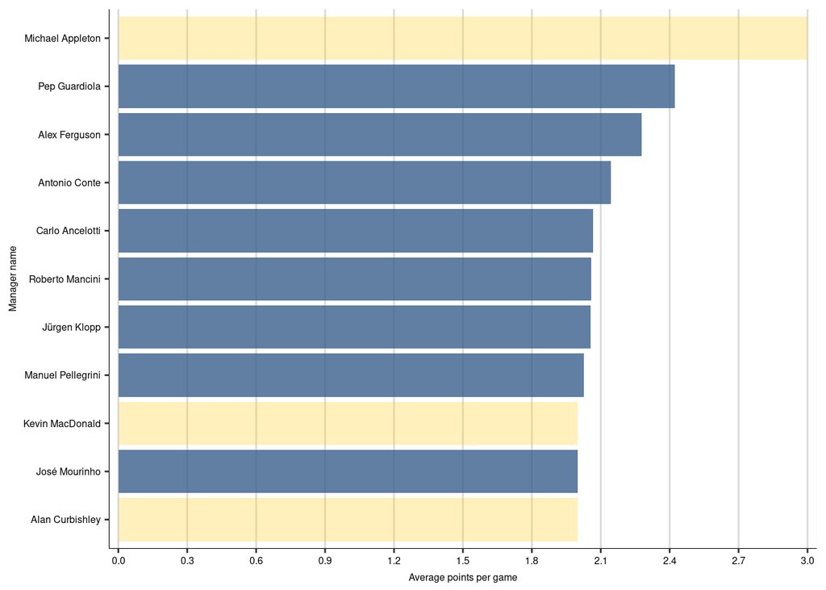

```r
# arranging per season and team
merged <- merged |>
  dplyr::arrange(season, team)

# considering average points per game as a measure of success
# 1. looking at the number of games managed per manager
games <- merged |>
  dplyr::group_by(team, manager_id, manager_name) |>
  dplyr::summarise(manager_games = n())

# 2. adding up the points earned over a career at a team (if manager worked for two teams, we consider it two cases)
points <- merged |>
  dplyr::group_by(team, manager_id, manager_name) |>
  dplyr::summarise(manager_points = sum(points))

# 3. once we have games and points, we divide total points by the number of games
avg_points <- merge(games, points, by = c("manager_id", "team", "manager_name")) |>
  dplyr::group_by(team, manager_id, manager_name) |>
  dplyr::mutate(manager_avg_points = (manager_points / manager_games)) |>
  dplyr::arrange(manager_avg_points)

# 4. ranking the results
avg_points <- avg_points |>
  dplyr::arrange(-manager_avg_points)

# 5. looking at those with at least 2 points per game
top_managers <- avg_points |>
  dplyr::filter(manager_avg_points >= 2)

# 6. denoting caretakers (less than 18 games)
top_managers <- top_managers |>
  dplyr::mutate(
    manager_avg_points0 = ifelse(manager_games < 18, manager_avg_points, NA),
    manager_avg_points1 = ifelse(manager_games > 18, manager_avg_points, NA)
  )

# adding new variable for plotting
top_managers <- top_managers |>
  dplyr::mutate(fill = case_when(
    manager_games < 18 ~ "1",
    manager_games > 18 ~ "0"
  ))

# plotting the results
p1 <- top_managers |>
  ggplot(aes(x = reorder(manager_name, manager_avg_points), y = manager_avg_points, fill = fill, alpha = fill)) +
  geom_col(show.legend = F) +
  ylab("Average points per game") +
  xlab("Manager name") +
  scale_fill_manual(values = c(color[1], color[4])) +
  scale_alpha_manual(values = c(0.8, 0.3)) +
  scale_y_continuous(expand = c(0.01, 0.01), limits = c(0, 3), breaks = seq(0, 3, 0.3)) +
  coord_flip() +
  theme_bg() +
  cowplot::background_grid(major = "x", minor = "none")
p1
```

# 4 CHAPTER 03: Exploratory Data Analysis (EDA)

## 4.1 Frequencies and Probabilities

The **absolute frequency**, or count, of a value of a variable is simply the number of observations with that particular value in the data. The **relative frequency** is the frequency expressed in relative, or percentage, terms: the proportion of observations with that particular value among all observations in the data. If a variable has missing values, this proportion can be relative to all observations including the missing values or only to observations with missing values.

**Probability** is a general concept that is closely related to relative frequency. Probability is a measure of the likelihood of an event. In the context of data, an event is *the occurrence of a particular value of a variable*. **The probability of an event is its relative frequency.** Probabilities are always between zero and one. We denote the probability of an event as
$$P(event)$$
, so that
$$0 <= P(event) <= 1$$
. Considering a single event, it either happens or does not. These two are mutually exclusive: the probability of an event happening and it also not happening is zero:
$$P(event&~even) = 0$$
.

## 4.2 Visualizing Distributions

Frequencies are summarized by distributions. The **distribution** of a variable gives the frequency of each value of the variable in the data, either in terms of absolute frequency (number of observations), or relative frequency (proportion or percent).

The simplest way to visualize a distribution is the **histogram**. For variables with many potential values, showing bars for each value is usually uninformative. Instead, it’s better to group the many values in fewer groupings or bins. Visual inspection of a histogram can inform us about the number and location of **modes**: these are peaks in the distribution that stand out from their immediate neighborhood.

**Density plots**, also called **kernel density estimates**, are an alternative to histograms for variables with many values.

## 4.3 Extreme Values

What it should be do with observations with extreme values of a variable depends on the role of the variable in our analysis. We distinguish a *y* variable and one or more *x* variables in the analysis. Typically, our analysis will aim to uncover patterns in how values of *y* tend to differ for observations that have different values of *x*. **Discarding observations with extreme *x* values narrows the scope of the comparisons.** In contrast, discarding observations with extreme *y* values changes the result of the comparisons.

```r
# load data
vienna <- read_csv("input/hotels-vienna.csv")

# looking at the frequencies of all types of accommodation
table(vienna$accommodation_type)
```

```
##
##         Apart-hotel           Apartment   Bed and breakfast         Guest House
##                   4                 124                   4                   8
##              Hostel               Hotel             Pension Vacation home Condo
##                   6                 264                  16                   2
```

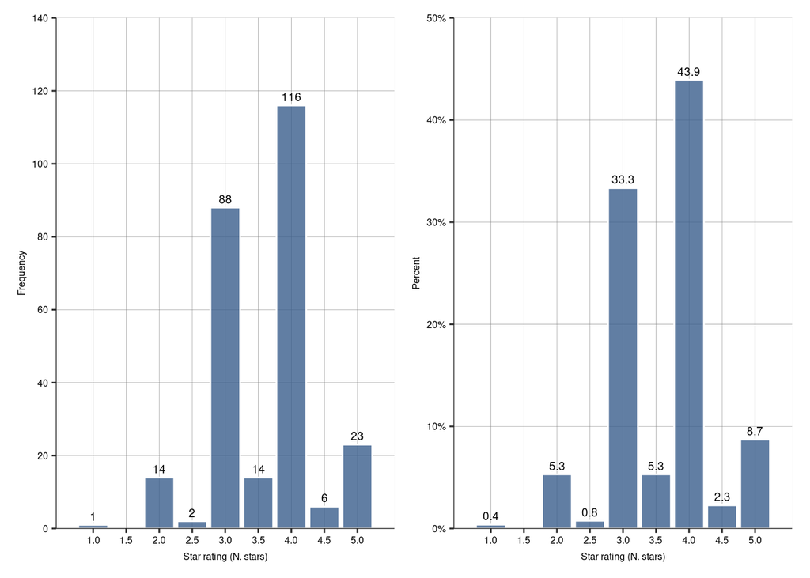

```r
# filtering accommodation: Hotel
vienna_hotels <- vienna |>
  dplyr::filter(accommodation_type == "Hotel")

# plotting distributions
# Absolute frequency (count)
p1 <- ggplot(data = vienna_hotels, aes(x = stars)) +
  geom_bar(color = color.outline, fill = color[1], alpha = 0.8, na.rm = T) +
  geom_text(stat = "count", aes(label = ..count..), vjust = -0.5, size = 2.5) +
  labs(x = "Star rating (N. stars)", y = "Frequency") +
  expand_limits(x = 0.01, y = 0.01) +
  scale_x_continuous(expand = c(0.01, 0.01), limits = c(0.5, 5.5), breaks = seq(1, 5, 0.5)) +
  scale_y_continuous(expand = c(0.00, 0.00), limits = c(0, 140), breaks = seq(0, 140, 20)) +
  theme_bg()

# Relative frequency (percent)
p2 <- ggplot(data = vienna_hotels, aes(x = stars, y = (..count..) / sum(..count..))) +
  geom_bar(color = color.outline, fill = color[1], alpha = 0.8, na.rm = T) +
  geom_text(stat = "count", aes(label = round((..count..) / sum(..count..) * 100, 1)), vjust = -0.5, size = 2.5) +
  labs(x = "Star rating (N. stars)", y = "Percent") +
  expand_limits(x = 0.01, y = 0.01) +
  scale_x_continuous(expand = c(0.01, 0.01), limits = c(0.5, 5.5), breaks = seq(1, 5, 0.5)) +
  scale_y_continuous(expand = c(0.00, 0.00), limits = c(0, 0.5), breaks = seq(0, 0.5, 0.1), labels = scales::percent_format(accuracy = 1)) +
  theme_bg()

p1|p2
```

```r
# filtering 3-4 stars, without 1000 euro extreme value
vienna_hotels <- vienna |>
  dplyr::filter(accommodation_type == "Hotel") |>
  dplyr::filter(stars >= 3 & stars <= 4) |>
  dplyr::filter(!is.na(stars)) |>
  dplyr::filter(price <= 1000)

table(vienna_hotels$city)
```

```
##
## Vienna
##    217
```

```r
table(vienna_hotels$stars)
```

```
##
##   3 3.5   4
##  87  14 116
```

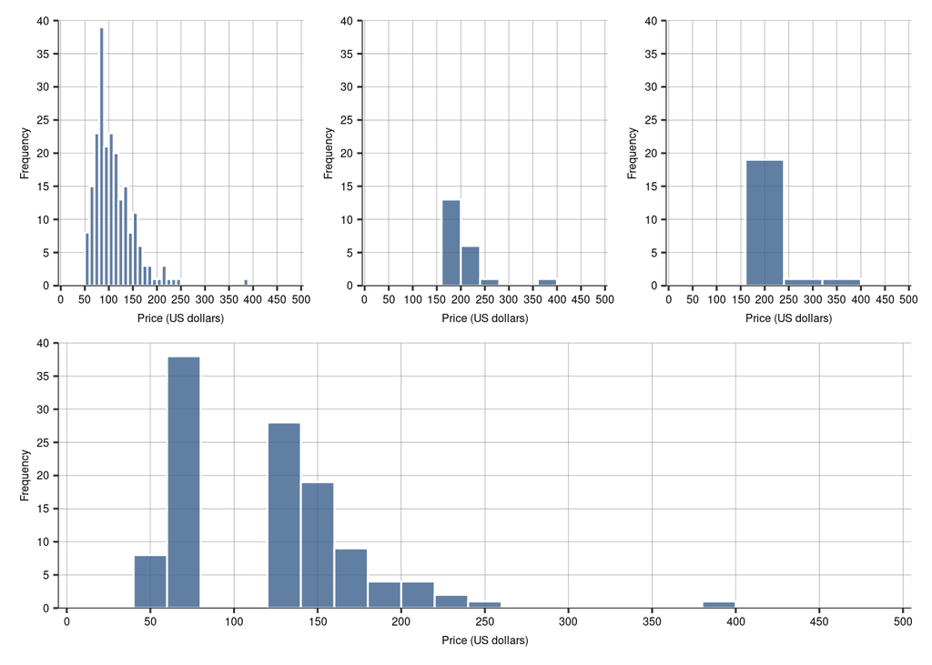

```r
# plotting hotel price (different bindwidth)
p3 <- ggplot(data = vienna_hotels, aes(x = price)) +
  geom_histogram_da(type = "frequency", binwidth = 10) +
  labs(x = "Price (US dollars)", y = "Frequency") +
  expand_limits(x = 0.01, y = 0.01) +
  coord_cartesian(clip = "off") +
  scale_x_continuous(expand = c(0.01, 0.01), limits = c(0, 500), breaks = seq(0, 500, by = 50)) +
  scale_y_continuous(expand = c(0.00, 0.00), limits = c(0, 40), breaks = seq(0, 40, by = 5)) +
  theme_bg()

p4 <- ggplot(data = vienna_hotels, aes(x = price)) +
  geom_histogram_da(type = "frequency", binwidth = 40) +
  labs(x = "Price (US dollars)", y = "Frequency") +
  expand_limits(x = 0.01, y = 0.01) +
  coord_cartesian(clip = "off") +
  scale_x_continuous(expand = c(0.01, 0.01), limits = c(0, 500), breaks = seq(0, 500, by = 50)) +
  scale_y_continuous(expand = c(0.00, 0.00), limits = c(0, 40), breaks = seq(0, 40, by = 5)) +
  theme_bg()

p5 <- ggplot(data = vienna_hotels, aes(x = price)) +
  geom_histogram_da(type = "frequency", binwidth = 80) +
  labs(x = "Price (US dollars)", y = "Frequency") +
  expand_limits(x = 0.01, y = 0.01) +
  coord_cartesian(clip = "off") +
  scale_x_continuous(expand = c(0.01, 0.01), limits = c(0, 500), breaks = seq(0, 500, by = 50)) +
  scale_y_continuous(expand = c(0.00, 0.00), limits = c(0, 40), breaks = seq(0, 40, by = 5)) +
  theme_bg()

p6 <- ggplot(data = vienna_hotels, aes(x = price)) +
  geom_histogram_da(type = "frequency", binwidth = 20) +
  labs(x = "Price (US dollars)", y = "Frequency") +
  expand_limits(x = 0.01, y = 0.01) +
  coord_cartesian(clip = "off") +
  scale_x_continuous(expand = c(0.01, 0.01), limits = c(0, 500), breaks = seq(0, 500, by = 50)) +
  scale_y_continuous(expand = c(0.00, 0.00), limits = c(0, 40), breaks = seq(0, 40, by = 5)) +
  theme_bg()

(p3 | p4 | p5) / p6
```

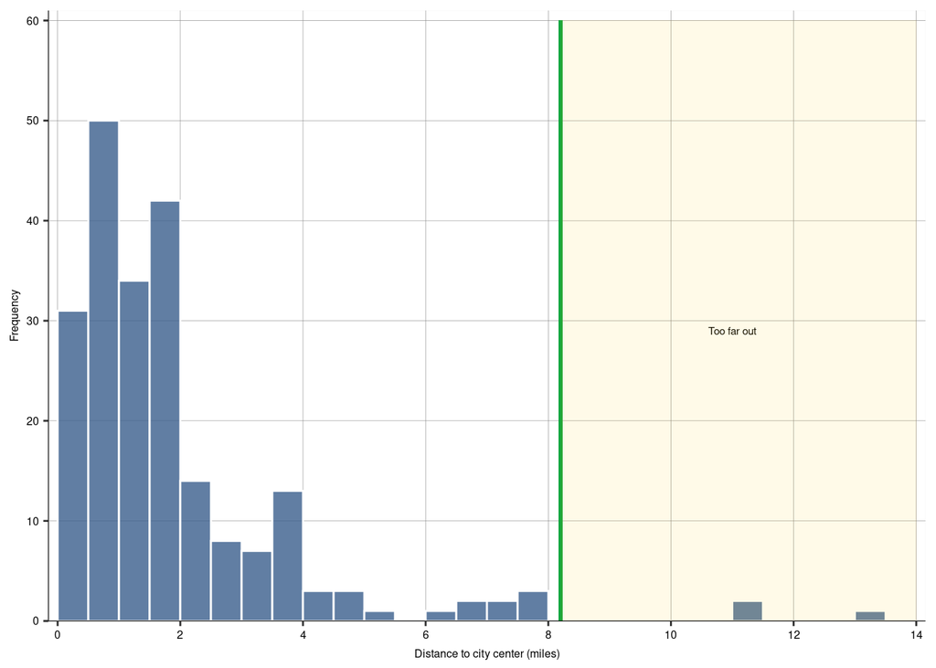

```r
# plotting distance
p7 <- ggplot(data = vienna_hotels, aes(x = distance)) +
  geom_histogram_da(type = "frequency", binwidth = 0.5) +
  labs(x = "Distance to city center (miles)", y = "Frequency") +
  expand_limits(x = 0.01, y = 0.01) +
  scale_x_continuous(expand = c(0.01, 0.01), limits = c(0, 14), breaks = seq(0, 14, by = 2)) +
  scale_y_continuous(expand = c(0.00, 0.00), limits = c(0, 61), breaks = seq(0, 60, by = 10)) +
  geom_segment(aes(x = 8.2, y = 0, xend = 8.2, yend = 60), color = color[2], size = 1) +
  # geom_segment(aes(x = 10, y = 40, xend = 8.4, yend = 40), arrow = arrow(length = unit(0.2, "cm")))+
  annotate("text", x = 11, y = 29, label = "Too far out", size = 2) +
  annotate("rect", xmin = 8.2, xmax = 14, ymin = 0, ymax = 60, fill = color[4], alpha = 0.1) +
  theme_bg()
p7
```

```r
# looking at the actual place of hotels (included outside the city of Vienna)
table(vienna_hotels$city_actual)
```

```
##
## Fischamend  Schwechat     Vienna Voesendorf
##          1          7        207          2
```

```r
# filtering 3-4 stars, less than 8miles from center, without 1000 euro extreme value
vienna_hotels <- vienna |>
  dplyr::filter(accommodation_type == "Hotel") |>
  dplyr::filter(stars >= 3 & stars <= 4) |>
  dplyr::filter(!is.na(stars)) |>
  dplyr::filter(price <= 1000) |>
  dplyr::filter(city_actual == "Vienna")
```

## 4.4 Summary Statistics for Quantitative Variables

While measures of central value (such as mean, median) and spread (such as range, standard deviation) are usually well known, summary statistics that measure **skewness** are less frequently used. A distribution may be skewed in two ways, having a long left tail or having a long right tail. A long left tail means having a few observations with large values with most observations having larger values. A long right tail means having a few observations with large values with most observations having smaller values. The statistic of skewness compares the mean and the median and is called the **mean-median measure of skewness**. When the distribution is symmetric, its mean and median are the same. When it is skewed with a long right tail, the mean is larger than the median. Conversely, when a distribution is skewed with a long left tail, the mean is smaller than the median. The mean-median measure of skewness captures this intuition. In order to make this measure comparable across various distributions, we use a standardized measure, dividing the difference by the standard deviation:
$$Skewness = \frac{\bar{x} - median[x]}{Std[x]}$$

```r
# CASE STUDY: Comparing Hotel Prices in Europe: Vienna vs London
# load data
hotels_europe_price <- read_csv("input/hotels-europe_price.csv")
hotels_europe_features <- read_csv("input/hotels-europe_features.csv")

# creating a working data table for analysis
hotels_europe <- dplyr::left_join(hotels_europe_price, hotels_europe_features, by = "hotel_id")

# filtering for same Vienna data we used + London same date
hotels_europe_london_viena <- hotels_europe |>
  dplyr::filter(year == 2017 & month == 11 & weekend == 0) |>
  dplyr::filter(city %in% c("Vienna", "London")) |>
  dplyr::filter(accommodation_type == "Hotel") |>
  dplyr::filter(stars >= 3 & stars <= 4) |>
  dplyr::filter(!is.na(stars)) |>
  dplyr::filter(city_actual %in% c("Vienna", "London")) |>
  dplyr::filter(price <= 600)

# looking at the mean price for both cities
hotels_europe_london_viena |>
  dplyr::group_by(city) |>
  dplyr::summarise(mean_price = mean(price), max = max(price), n = n())
```

```
## # A tibble: 2 × 4
##   city   mean_price   max     n
##   <chr>       <dbl> <dbl> <int>
## 1 London       202.   491   435
## 2 Vienna       110.   383   207
```

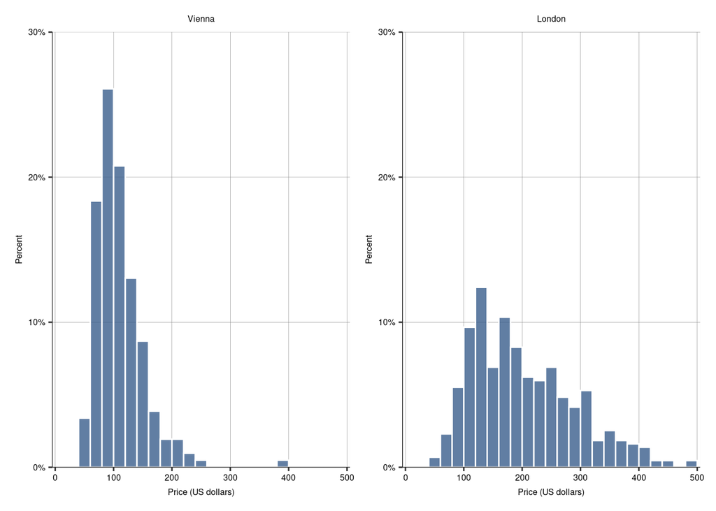

```r
# plotting the distribution of hotel price
p1 <- ggplot(data = filter(hotels_europe_london_viena, city == "Vienna"), aes(x = price)) +
  geom_histogram_da(type = "percent", binwidth = 20) +
  labs(x = "Price (US dollars)", y = "Percent", title = "Vienna") +
  scale_x_continuous(expand = c(0.01, 0.01), limits = c(0, 500), breaks = seq(0, 500, by = 100)) +
  scale_y_continuous(expand = c(0.00, 0.00), limits = c(0, 0.3), breaks = seq(0, 0.3, by = 0.1), labels = scales::percent_format()) +
  theme_bg()

p2 <- ggplot(data = filter(hotels_europe_london_viena, city == "London"), aes(x = price)) +
  geom_histogram_da(type = "percent", binwidth = 20) +
  labs(x = "Price (US dollars)", y = "Percent", title = "London") +
  scale_x_continuous(expand = c(0.01, 0.01), limits = c(0, 500), breaks = seq(0, 500, by = 100)) +
  scale_y_continuous(expand = c(0.00, 0.00), limits = c(0, 0.3), breaks = seq(0, 0.3, by = 0.1), labels = scales::percent_format()) +
  theme_bg()

(p1 | p2)
```

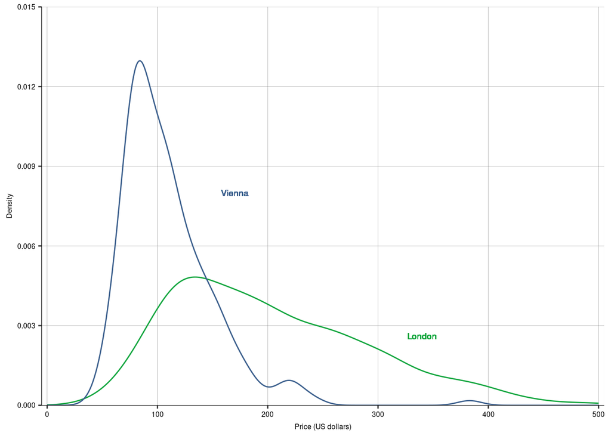

```r
# plotting same data using density plot
p3 <- ggplot(data = hotels_europe_london_viena, aes(x = price, y = stat(density), color = city)) +
  geom_line(stat = "density", show.legend = F, na.rm = TRUE) +
  labs(x = "Price (US dollars)", y = "Density", color = "") +
  scale_color_manual(
    name = "",
    values = c(color[2], color[1]),
    labels = c("London", "Vienna")
  ) +
  scale_y_continuous(expand = c(0.0, 0.0), limits = c(0, 0.015), breaks = seq(0, 0.015, by = 0.003)) +
  scale_x_continuous(expand = c(0.01, 0.01), limits = c(0, 500), breaks = seq(0, 500, by = 100)) +
  geom_text(aes(x = 340, y = 0.0026, label = "London"), color = color[2], size = 2.5) +
  geom_text(aes(x = 170, y = 0.008, label = "Vienna"), color = color[1], size = 2.5) +
  theme_bg()
p3
```

```r
# summarizing all statistics in one table
hotels_europe_london_viena_tab <- hotels_europe_london_viena |>
  dplyr::group_by(city) |>
  dplyr::summarise(
    n = length(price), mean = mean(price), median = median(price), min = min(price), max = max(price),
    sd = sd(price), skew = ((mean(price) - median(price)) / sd(price))
  )
hotels_europe_london_viena_tab
```

```
## # A tibble: 2 × 8
##   city       n  mean median   min   max    sd  skew
##   <chr>  <int> <dbl>  <dbl> <dbl> <dbl> <dbl> <dbl>
## 1 London   435  202.    186    49   491  88.1 0.186
## 2 Vienna   207  110.    100    50   383  42.2 0.236
```

```r
# CASE STUDY: Measuring Home Team Advantage in Football
# load data
games <- read_csv("input/epl_games.csv")

# looking at 2016/17 season only
games <- subset(games, season == 2016)

# adding a goal difference variable
games <- games |>
  dplyr::mutate(home_goaladv = goals_home - goals_away)

# summary statistics
summary(games$home_goaladv)
```

```
##    Min. 1st Qu.  Median    Mean 3rd Qu.    Max.
## -6.0000 -1.0000  0.0000  0.3947  2.0000  5.0000
```

```r
psych::describe(games$home_goaladv)
```

```
##    vars   n mean   sd median trimmed  mad min max range  skew kurtosis  se
## X1    1 380 0.39 1.91      0    0.43 1.48  -6   5    11 -0.25     0.15 0.1
```

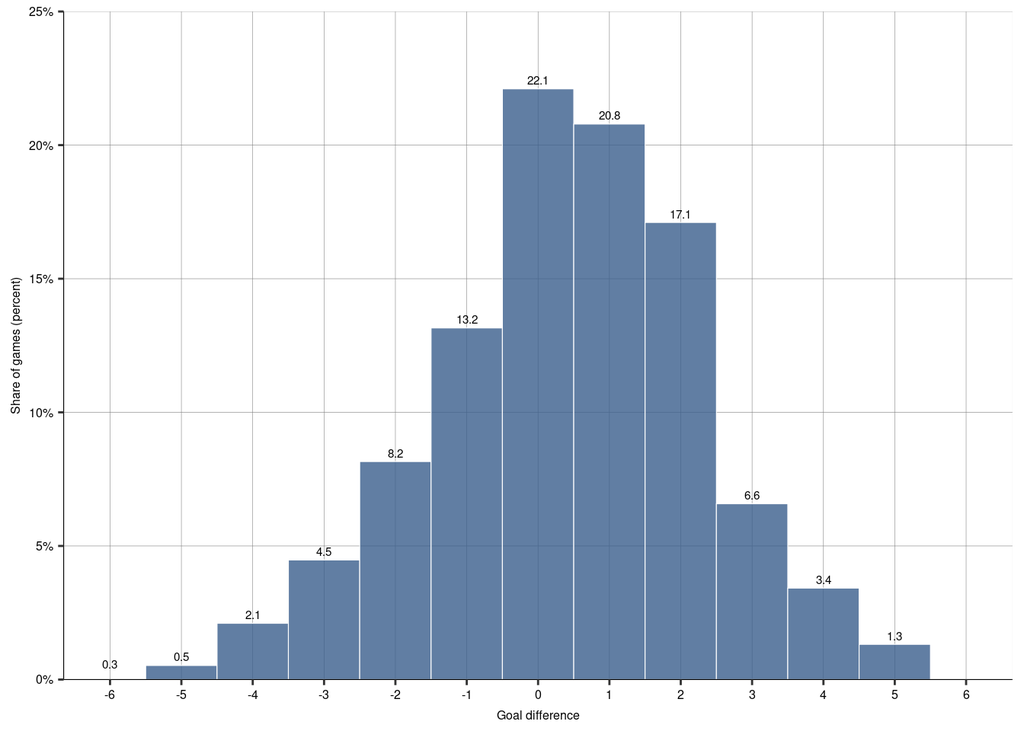

```r
# plotting the distribution of the goal difference variable
p1 <- ggplot(data = games, aes(x = home_goaladv, y = (..count..) / sum(..count..))) +
  geom_histogram(
    color = color.outline, fill = theme_colors[1],
    size = 0.2, alpha = 0.8, show.legend = F, na.rm = TRUE,
    binwidth = 1
  ) +
  geom_text(stat = "count", aes(label = round((..count..) / sum(..count..) * 100, 1)), hjust = 0.5, vjust = -0.5, size = 2) +
  labs(x = "Goal difference", y = "Share of games (percent)") +
  scale_x_continuous(expand = c(0.05, 0.05), limits = c(-6, 6), breaks = seq(-6, 6, by = 1)) +
  scale_y_continuous(expand = c(0, 0), limits = c(0, 0.25), breaks = seq(0, 0.25, by = 0.05), labels = scales::percent_format(accuracy = 5L)) +
  theme_bg()
p1
```

### 4.4.1 Tables

To produce a good table, one needs to to think about its **usage**, choose **encoding** and **scaffolding** accordingly, and may add **annotation**. One important type wants to communicate the main result, or results, of the analysis. A table of this type is called a **result table**, or a communication table. Good communication tables are focused on one message. The other main table type is the **documentation table**. Its aim is to document exploratory data analysis. Documentation tables describe the structure of the data, one or more variables, or some other features such as missing values or extreme values. Such tables are also used to summarize the results of data cleaning and restructuring processes by showing numbers of observations and statistics of important variables for the original data and the data we chose to work with.

Encoding here means what numbers to present, and in what detail. Documentation tables tend to be large and include everything that is, or may become, important. In contrast, communication tables should be simple and focused. A good practice of encoding is to show totals together with components. In a documentation table with numbers of observations in subgroups in the data, the total number of observations is usually included. Another good practice is to include the number of observations in all tables. The second question of encoding is how much detail the numbers should have in the table. Communication tables should have no more detail than necessary. Usually, documentation tables have numbers in more detail.

```python
# We calculated the mean, the standard deviation of the goal difference and the relative frequency of games

# importing the library
import pandas as pd

# converting R object to a python object
wms = r.games
wms.shape

# calculating the goal difference
```

```
## (380, 10)
```

```python
wms["home_goaladv"] = wms["goals_home"] - wms["goals_away"]
wms.head()

# making a table to present the results
```

```
##   div  season       date  ... goals_home goals_away  home_goaladv
## 0  E0  2016.0  13aug2016  ...        1.0        1.0           0.0
## 1  E0  2016.0  13aug2016  ...        0.0        1.0          -1.0
## 2  E0  2016.0  13aug2016  ...        1.0        1.0           0.0
## 3  E0  2016.0  13aug2016  ...        0.0        1.0          -1.0
## 4  E0  2016.0  13aug2016  ...        2.0        1.0           1.0
##
## [5 rows x 10 columns]
```

```python
pd.DataFrame.from_dict(
    {
        "Statistics": [
            "Mean",
            "Standard deviation",
            "Percent positive",
            "Percent zero",
            "Percent negative",
            "Number of observations",
        ],
        "Value": [
            wms["home_goaladv"].describe()["mean"],
            wms["home_goaladv"].describe()["std"],
            (wms["home_goaladv"] > 0).sum() / wms["home_goaladv"].shape[0] * 100,
            (wms["home_goaladv"] == 0).sum() / wms["home_goaladv"].shape[0] * 100,
            (wms["home_goaladv"] < 0).sum() / wms["home_goaladv"].shape[0] * 100,
            wms["home_goaladv"].describe()["count"],
        ],
    }
).round(1)
```

```
##                Statistics  Value
## 0                    Mean    0.4
## 1      Standard deviation    1.9
## 2        Percent positive   49.2
## 3            Percent zero   22.1
## 4        Percent negative   28.7
## 5  Number of observations  380.0
```

## 4.5 Theoretical Distributions

Theoretical distributions are distributions of variables with idealized properties. Instead of showing frequencies in data, they show more abstract probabilities: the likelihood of each value (or each interval of values) in a more abstract setting. That more abstract setting is a hypothetical “data” or “population”, or the abstract space of the possible realizations of events.

They can be of great help when we want to understand important characteristics of variables in our data. If a variable in our data is well approximated by a theoretical distribution, we can simply attribute those properties to the variable without having to check those properties over and over. Another reason to know about theoretical distributions is that some of them are useful what happens when we want to generalize from the data we have.

The **normal distribution** is a pure theoretical construct in the sense that it was derived mathematically from another distribution, the **binomial**. Variables with a normal distribution can in principle take on any value from negative infinity to positive infinity. The histogram of the normal distribution is bell shaped, and is characterized by two **parameters**, usually denoted as $\mu$ and standard deviation $\sigma$. They refer to the mean ($\mu$) and the standard deviation ($\sigma$). A special case of the normal distribution is the **standard normal distribution**. It is a normal distribution with parameters $\mu = 0$ and $\sigma = 1$. If variable *x* is normally distributed with mean $\mu$ and standard deviation $\sigma$, its transformed version is distributed standard normal if we take out the mean and divide this difference by the standard deviation: $\frac{(x-\mu)}{\sigma}$.

It turns out that when we transform a normally distributed variable by adding or multiplying by a number, the result is another normally distributed variable, with appropriately transformed mean and standard deviation. It also turns out that when we add two normally distributed variables, the resulting variable is also normally distributed, and its mean is the sum of the means of the two original variables.

Some variables in real life are well approximated by the normal distribution. However, the normal is a bad approximation to real-life variables with extreme values. Extreme values are very unlikely in the normal distribution. Besides the absence of extreme values, symmetry is another feature of the normal distribution that makes it a bad approximation to many economic variables. Earnings, income, wealth, and firm productivity are usually asymmetrically distributed with a long right tails. One theoretical distribution that may be a better approximation to such variables is the lognormal distribution.

The **lognormal distribution** is very asymmetric, with a long right tail, potentially including many extreme values at the positive end. The lognormal distribution is derived from the normal distribution. If we take a variable that is distributed normally *(x)* and raise *e* to its power ($e^x$), the resulting variable is distributed lognormally. The old variable is the **natural logarithm** of the new variable. Because we raised *e* to the power of the original variable, the values of the resulting lognormal variable are always positive. They range between zero and positive infinity (never reaching either). By convention, the parameters of the lognormal are the mean $\mu$ and the standard deviation $\sigma$ of the original, normally distributed variable, which is the logarithm of the new variable. There are real-life variables that are approximately lognormally distributed. These include distributions of price, income, and firm size. Variables are well approximated by the lognormal if they are the result of many things multiplied together (the natural log of them is thus a sum).

```r
# CASE STUDY: Distributions of Body Height and Income
# load data
hrs <- read_csv("input/hrs_height_income.csv")

# parsing height var as numeric
hrs$height <- as.numeric(as.character(hrs$height))

# looking at the overall height distribution
Hmisc::describe(hrs$height)
```

```
## hrs$height
##        n  missing distinct     Info     Mean      Gmd      .05      .10
##    18660       87      100    0.996    1.678   0.1175    1.524    1.549
##      .25      .50      .75      .90      .95
##    1.600    1.676    1.753    1.829    1.854
##
## lowest : 1.0033 1.2192 1.2319 1.2446 1.2700, highest: 2.0320 2.0574 2.0701 2.1082 2.3241
```

```r
# filtering height of women age 55-59
filtered_women_height <- hrs |>
  dplyr::filter(age >= 55 & age < 60 & female == 1 & height > 1.3 & height < 2.1)

Hmisc::describe(filtered_women_height$height)
```

```
## filtered_women_height$height
##        n  missing distinct     Info     Mean      Gmd      .05      .10
##     1988        0       50    0.991    1.629  0.07942    1.524    1.549
##      .25      .50      .75      .90      .95
##    1.575    1.626    1.676    1.727    1.753
##
## lowest : 1.3462 1.3716 1.4097 1.4224 1.4478, highest: 1.8034 1.8161 1.8288 1.8542 1.9050
```

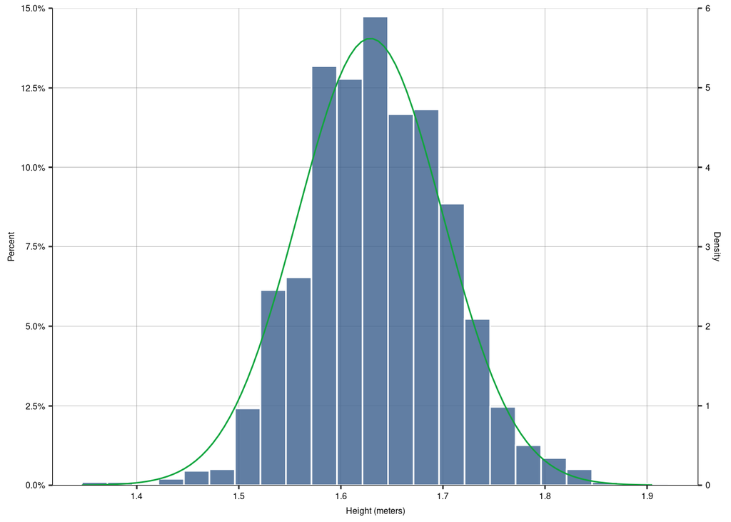

```r
# plotting women height
p1 <- ggplot(filtered_women_height, aes(x = height)) +
  geom_histogram(aes(y = ..density..),
    binwidth = 0.025, boundary = min(filtered_women_height$height),
    fill = color[1], color = color.outline, alpha = 0.8, closed = "left"
  ) +
  stat_function(
    fun = dnorm, colour = color[2],
    args = with(filtered_women_height, c(mean = mean(height), sd = sd(height)))
  ) +
  scale_y_continuous("Density",
    position = "right", expand = c(0, 0), limits = c(0, 6),
    sec.axis = sec_axis(~ . * 0.025, name = "Percent", breaks = seq(0, 0.15, by = 0.025), labels = percent_format(accuracy = 0.1))
  ) +
  theme_bg() +
  xlab("Height (meters)")
p1
```

```r
# filtering income of women age 55-69
filtered_women_income <-  hrs  |>
  dplyr::filter(age >= 55 & age < 60 & female == 1 & hhincome > 1 & hhincome < 1000)

Hmisc::describe(filtered_women_income$hhincome)
```

```
## filtered_women_income$hhincome
##        n  missing distinct     Info     Mean      Gmd      .05      .10
##     1918        0     1470        1    74.93    78.29    6.924    9.878
##      .25      .50      .75      .90      .95
##   19.704   48.000  100.800  170.474  226.275
##
## lowest :   1.2000   1.4000   1.4280   1.5000   1.5600
## highest: 695.8052 705.2400 805.2000 921.6000 945.0000
```

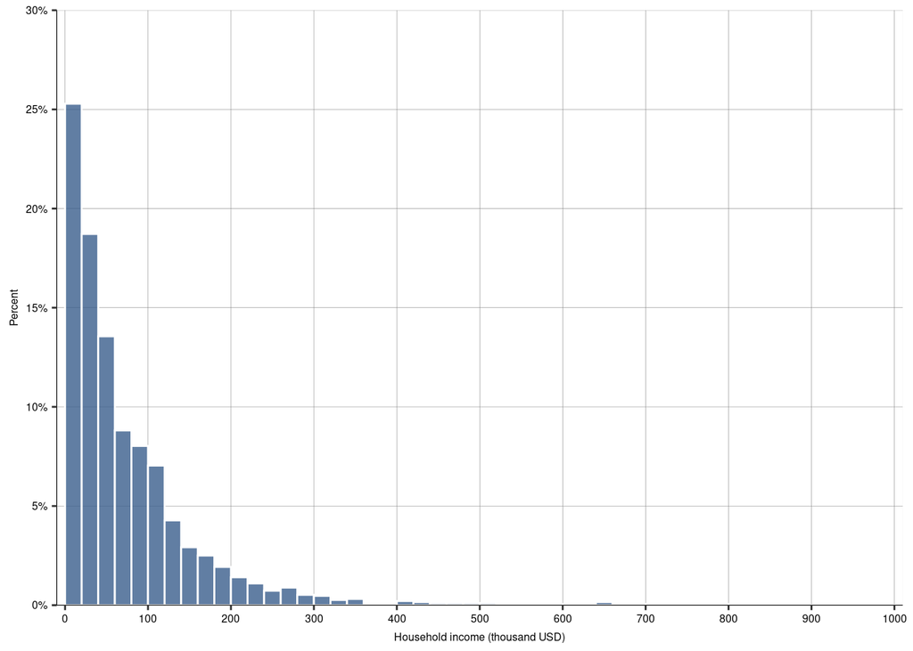

```r
# plotting income histogram
p2 <- ggplot(filtered_women_income, aes(x = hhincome)) +
  geom_histogram(aes(y = (..count..) / sum(..count..)),
    binwidth = 20, boundary = 0, closed = "left",
    fill = color[1], color = color.outline, alpha = 0.8
  ) +
  ylab("Percent") +
  xlab("Household income (thousand USD)") +
  expand_limits(x = 0.01, y = 0.01) +
  scale_x_continuous(expand = c(0.01, 0.01), limits = c(0, 1000), breaks = seq(0, 1000, by = 100)) +
  scale_y_continuous(expand = c(0.00, 0.00), limits = c(0, 0.3), breaks = seq(0, 0.3, by = 0.05), labels = scales::percent_format(accuracy = 1)) +
  theme_bg()
p2
```

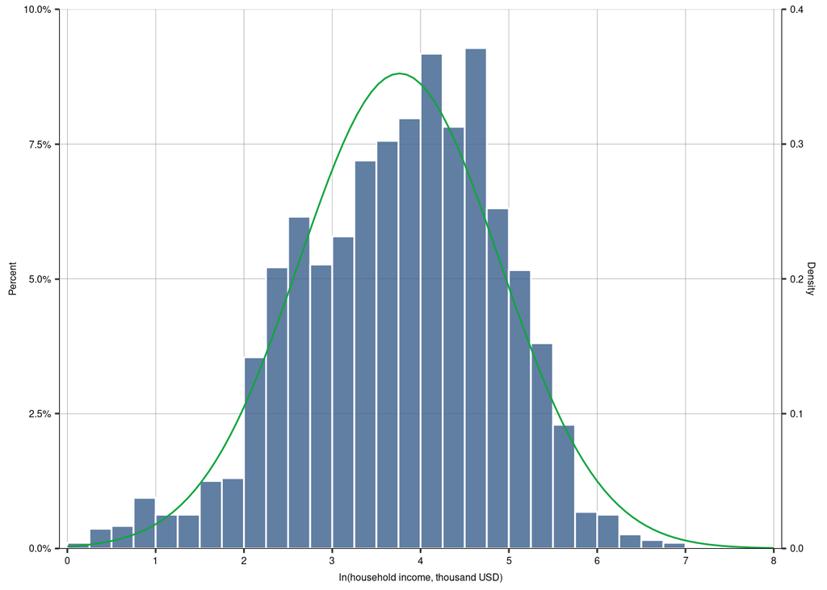

```r
# log of household income
filtered_women_income <- filtered_women_income |>
  dplyr::mutate(lnincome = log(hhincome))

# plotting log of household income
p3 <- ggplot(filtered_women_income, aes(x = lnincome)) +
  geom_histogram(aes(y = ..density..),
    binwidth = 0.25, boundary = 0, closed = "left",
    fill = color[1], color = color.outline, alpha = 0.8
  ) +
  stat_function(
    fun = dnorm, colour = color[2],
    args = with(filtered_women_income, c(mean = mean(lnincome), sd = sd(lnincome)))
  ) +
  scale_x_continuous(expand = c(0.01, 0.01), limits = c(0, 8), breaks = seq(0, 8, by = 1)) +
  scale_y_continuous("Density",
    position = "right", expand = c(0, 0), limits = c(0, 0.4),
    sec.axis = sec_axis(~ . * 0.25,
      name = "Percent", breaks = seq(0, 0.1, by = 0.025),
      labels = percent_format(accuracy = 0.1)
    )
  ) +
  theme_bg() +
  ylab("Percent") +
  xlab("ln(household income, thousand USD)")
p3
```

# 5 CHAPTER 04: Comparison and Correlation

Much of data analysis is built on comparing values of a *y* variable by values of an *x* variable, or more *x* variables. Such a comparison can uncover the **patterns of association** between the two variables: whether and how observations with particular values of one variable *(x)* tend to have particular values of the other variable *(y)*.

The role of *y* is different from the role of *x*. It’s the values of *y* we are interested in, and we compare observations that are different in their *x* values. This asymmetry comes from the goal of our analysis. One goal of data analysis is predicting the value of a *y* variable with the help of other variables. The prediction itself takes place when we know the values of those other variables but not the *y* variable. To predict *y* based on the other variables we need a rule that tells us what the predicted *y* value is as a function of the values of the other variables. Such a rule can be devised by analyzing data where we know the *y* values, too.

The other most frequent goal of data analysis is to learn about the effect of a **causal variable** *x* on an **outcome variable** *y*. Here, we typically are interested in what the value of *y* would be if we could change *x*.

In sum, deciding on what’s *y* and what’s *x* in the data is the first step before doing any meaningful analysis.

- For prediction we want to know what value of *y* to expect for different values of various *x* variables, such $x_1$, $x_2$,…
- For causal analysis we want to know what value of *y* to expect if we changed the value of *x*, often comparing observations that are similar in other variables $(z_1)$, $(z_2)$, …

```r
# CASE STUDY: Management quality and firm size: describing patterns of association
# load data
wms <- read_csv("input/wms_da_textbook.csv")

# sample selection
wms <- wms |>
  dplyr::filter(country=="Mexico" & wave==2013 & emp_firm>=100  & emp_firm<=5000)

# summary
summary(wms$emp_firm)
```

```
##    Min. 1st Qu.  Median    Mean 3rd Qu.    Max.
##   100.0   200.0   353.0   761.1   900.0  5000.0
```

```r
Hmisc::describe(wms$emp_firm)
```

```
## wms$emp_firm
##        n  missing distinct     Info     Mean      Gmd      .05      .10
##      300        0      108    0.999    761.1    855.6    119.8    144.5
##      .25      .50      .75      .90      .95
##    200.0    353.0    900.0   2000.0   3000.0
##
## lowest :  100  110  115  116  120, highest: 3600 3957 4000 4500 5000
```

```r
wms  |>
  dplyr::select(management, emp_firm)  |>
  dplyr::summarise_all(tibble::lst(min, max, mean, median, sd, length))
```

```
## # A tibble: 1 × 12
##   management_min emp_firm_min management_max emp_firm_max management_mean
##            <dbl>        <dbl>          <dbl>        <dbl>           <dbl>
## 1           1.28          100           4.61         5000            2.94
## # … with 7 more variables: emp_firm_mean <dbl>, management_median <dbl>,
## #   emp_firm_median <dbl>, management_sd <dbl>, emp_firm_sd <dbl>,
## #   management_length <int>, emp_firm_length <int>
```

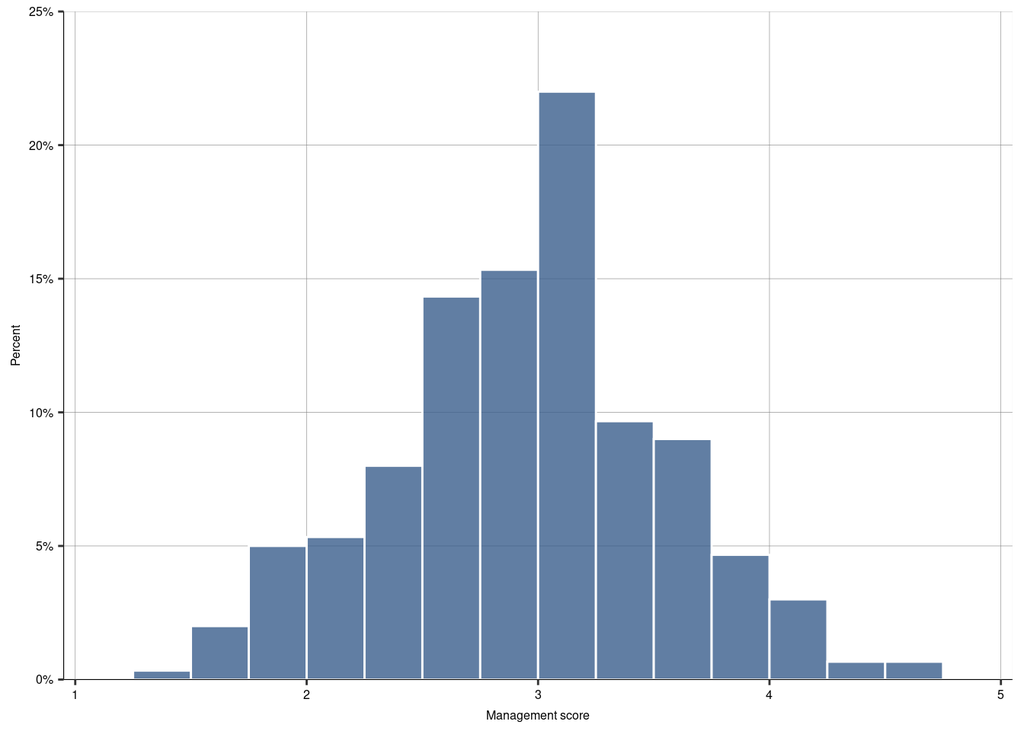

```r
# plotting distribution of the management score
p1 <- ggplot(data = wms, aes(x = management)) +
  geom_histogram_da(binwidth = 0.25, type = "percent", boundary = 0) +
  labs(x = "Management score", y = "Percent") +
  scale_x_continuous(expand = c(0.01, 0.01), limits = c(1, 5)) +
  scale_y_continuous(expand = c(0.00, 0.00), limits = c(0, 0.25), breaks = seq(0, 0.25, by = 0.05), labels = scales::percent_format(accuracy = 1)) +
  theme_bg()
p1
```

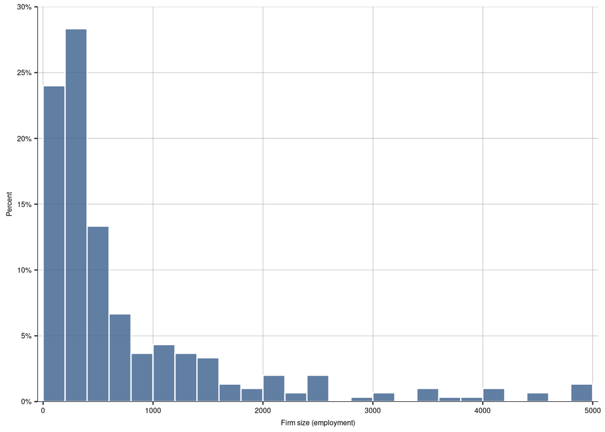

```r
# plotting the distribution of employees
p2 <- ggplot(data = wms, aes(x = emp_firm)) +
  geom_histogram_da(binwidth = 200, type = "percent") +
  labs(x = "Firm size (employment)", y = "Percent") +
  scale_x_continuous(expand = c(0.01, 0.01), limits = c(0, 5000), breaks = seq(0, 5000, by = 1000)) +
  scale_y_continuous(expand = c(0.00, 0.00), limits = c(0, 0.3), breaks = seq(0, 0.3, by = 0.05), labels = scales::percent_format(accuracy = 1)) +
  theme_bg()
p2
```

```r
# creating variable log
wms$lnemp = log(wms$emp_firm)
Hmisc::describe(wms$lnemp)
```

```
## wms$lnemp
##        n  missing distinct     Info     Mean      Gmd      .05      .10
##      300        0      108    0.999    6.082    1.119    4.786    4.973
##      .25      .50      .75      .90      .95
##    5.298    5.866    6.802    7.601    8.006
##
## lowest : 4.605170 4.700480 4.744932 4.753590 4.787492
## highest: 8.188689 8.283241 8.294050 8.411833 8.517193
```

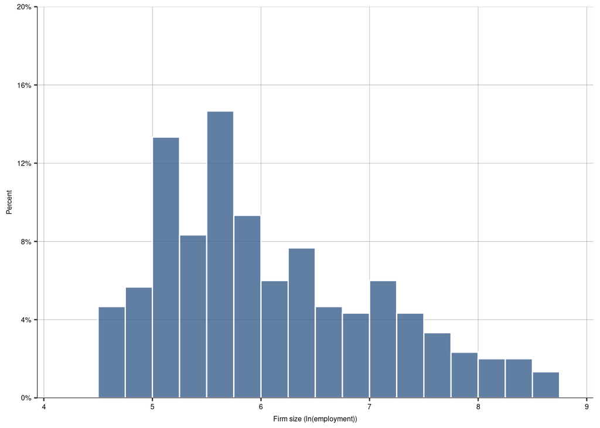

```r
# plotting the natural log of number of employees
p3 <- ggplot(data = wms, aes(x = lnemp)) +
  geom_histogram_da(binwidth = 0.25, type = "percent", boundary = 0) +
  labs(x = "Firm size (ln(employment))", y = "Percent") +
  scale_x_continuous(expand = c(0.01, 0.01), limits = c(4, 9)) +
  scale_y_continuous(expand = c(0.00, 0.00), limits = c(0, 0.2), breaks = seq(0, 0.2, by = 0.04), labels = scales::percent_format(accuracy = 1)) +
  theme_bg()
p3
```

## 5.1 Conditioning

The word statisticians use for comparison is **conditioning**. When we compare the values of *y* by the values of *x*, we condition *y* on *x*. *y* is also called the **outcome variable**; *x* is also called the **conditioning (or predictor) variable**.

When data analysts want to uncover values of *y* for observations that are different in *x* but similar in *z*, they do one more step of conditioning: they compare *y* by *x* conditional on *z*. That is called **further conditioning** or a **conditional comparison**. In practice we explore conditional probabilities, conditional means, and conditional distributions.

### 5.1.1 Conditional Probabilities

The probability of a value of a variable in a data set is its relative frequency (percentage). **Conditional probability** is the probability of one event if another event happens. The event the conditional probability is about is called the **conditional event**; the other event is called the **conditioning event**. Conditional probabilities are denoted as $P(event_1\ |\ event_2)$: the probability of $event_1$ conditional on $event_2$.

Joint probabilities are related to conditional probabilities. The **joint probability** of two events is the probability that both occur: $P(event_1\ \&\ event_2)$. When two events are mutually exclusive, their joint probability is zero (the two never happen together).

Another probability related to two events denotes the likelihood that one event or the other happens. This is the sum of the two probabilities minus their joint probability: $P(event_1\ OR\ event_2) = P(event_1) + P(event_2) - P(event_1\ \&\ event_2)$. If the two events are mutually exclusive, we subtract zero from the sum of the two probabilities.

The conditional probability can be expressed as the corresponding joint probability divided by the probability of the conditioning event:
$$P(event_1\ |\ event_2) = \frac{P(event_1\ \&\ event_2)}{P(event_2)}$$
Two events are **independent** if the probability of one of the events is the same regardless of whether or not the other event occurs. In the language of conditional probabilities this means that the conditional probabilities are the same as the unconditional probabilities: $P(event_1\ |\ event_2) = P(event_1)$ and $P(event_2\ |\ event_1) = P(event_2)$. Less intuitive, but also true is that the joint probability of independent events equals the product of their individual probabilities: $P(event_1\ \&\ event_2) = P(event_1)\ X\ P(event_2)$.

In data, the events refer to values of variables. Often, the conditional variable, *y*, is a binary variable: *y = 0* or *y = 1*. Then the conditional probability is the probability that *y = 1* if *x* has some value: $P(y = 1|x = value)$. Since *y* is binary, we know the probability of *y = 0* if we know the probability of *y = 1*, be it a conditional or unconditional probability. When *x* is binary too, there are two conditional probabilities:
$$P(y = 1\ |\ x = 1)$$
$$P(y = 1\ |\ x = 0)$$
With more values for either of the two variables *(y, x)*, we have more numbers to compare: $P(y = value\ |\ x = value)$. With relatively few values, visualization often helps. To visualize conditional probabilities if both *y* and *x* have few values, a good visualization is to show stacked bar charts of *y* for the values of *x*.

```r
# CASE STUDY: Management quality and firm size: describing patterns of association
# generating employment bins
wms$emp3bins <- ifelse(wms$emp_firm < 200, 1,
  ifelse(wms$emp_firm >= 200 & wms$emp_firm < 1000, 2,
    ifelse(wms$emp_firm >= 1000, 3, 100)
  )
)

Hmisc::describe(wms$emp3bins)
```

```
## wms$emp3bins
##        n  missing distinct     Info     Mean      Gmd
##      300        0        3    0.832        2    0.732
##
## Value         1    2    3
## Frequency    72  156   72
## Proportion 0.24 0.52 0.24
```

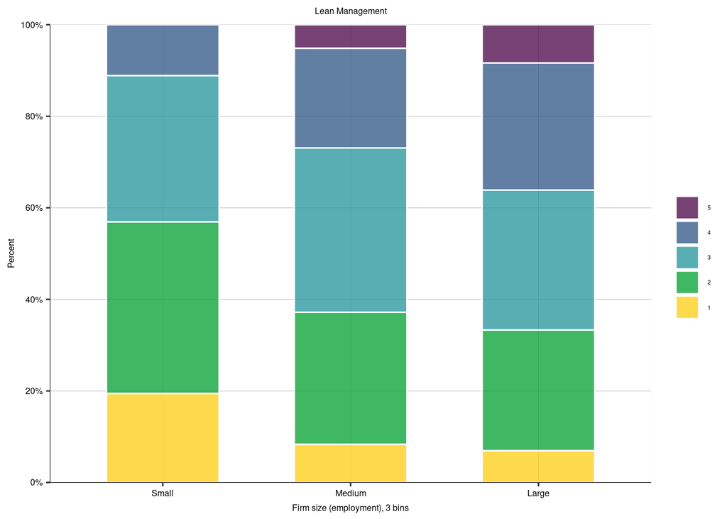

```r
# converting created variable as factor
wms$emp3bins <- as.factor(wms$emp3bins)

# creating new wms for lean management
wms_lean <- wms |>
  dplyr::select(emp3bins, lean1) |>
  dplyr::group_by(emp3bins, lean1) |>
  dplyr::summarise(Count = n()) |>
  dplyr::mutate(Percent = round(Count / sum(Count), digits = 5)) |>
  dplyr::ungroup() # use |> ungroup() when do multiple times group_by

# plotting lean management
p1 <- ggplot(data = wms_lean, aes(x = emp3bins, y = Percent, fill = factor(lean1, levels = rev(unique(lean1))))) +
  geom_bar(stat = "identity", position = "fill", width = 0.6, color = "white", size = 0.5, alpha = 0.8) +
  scale_y_continuous(expand = c(0, 0), limits = c(0, 1), breaks = seq(0, 1, by = 0.2), labels = scales::percent_format()) +
  scale_x_discrete(labels = c("1" = "Small", "2" = "Medium", "3" = "Large")) +
  scale_fill_manual(values = c(color[3], color[1], color[5], color[2], color[4]), name = NULL) +
  labs(x = "Firm size (employment), 3 bins", y = "Percent", title = "Lean Management") +
  theme_bg() +
  theme(legend.position = "right")
p1
```

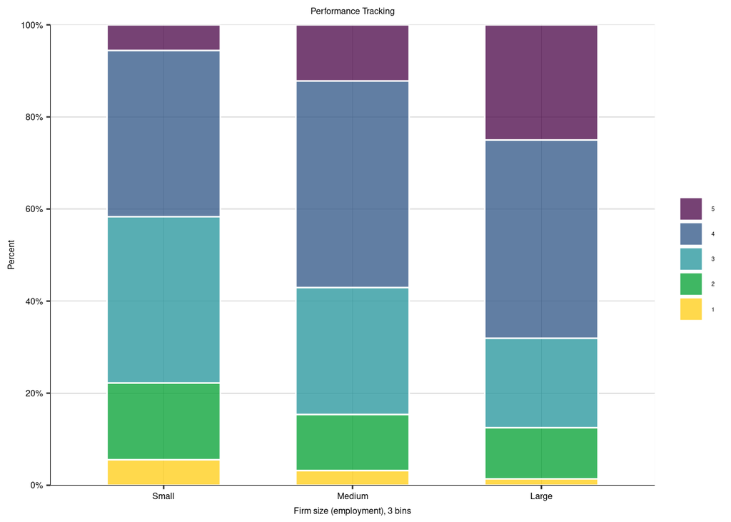

```r
# creating new wms for performance tracking
wms_per <- wms |>
  dplyr::select(emp3bins, perf2) |>
  dplyr::group_by(emp3bins, perf2) |>
  dplyr::summarise(Count = n()) |>
  dplyr::mutate(Percent = round(Count / sum(Count), digits = 5)) |>
  dplyr::ungroup()

# plotting performance tracking
p2 <- ggplot(data = wms_per, aes(x = emp3bins, y = Percent, fill = factor(perf2, levels = rev(unique(perf2))))) +
  geom_bar(stat = "identity", position = "fill", width = 0.6, color = "white", size = 0.5, alpha = 0.8) +
  scale_y_continuous(expand = c(0, 0), limits = c(0, 1), breaks = seq(0, 1, by = 0.2), labels = scales::percent_format()) +
  scale_x_discrete(labels = c("1" = "Small", "2" = "Medium", "3" = "Large")) +
  scale_fill_manual(values = c(color[3], color[1], color[5], color[2], color[4]), name = NULL) +
  labs(x = "Firm size (employment), 3 bins", y = "Percent", title = "Performance Tracking") +
  theme_bg() +
  theme(legend.position = "right")
p2
```

### 5.1.2 Conditional Distribution and Conditional Expectation

Just as all variables have a distribution, all *y* variables have a **conditional distribution** if conditioned on an *x* variable. The simplest case is a binary *x* when the conditional distribution of *y* is two distributions, one for each of the two *x* values.

Conditional distributions with few *x* values are best presented by visualization: for each *x* value we show stacked bar charts if *y* has few values or histograms if *y* is a quantitative variable with many values. Make sure that the histograms are fully comparable across the *x* values: most importantly, they have the same bins of *y*, and they have the same scale on the vertical axis. Comparing histograms can reveal qualitative differences in the distributions. To make quantitative comparisons, however, we need to compare statistics that summarize the important features of distributions.

The most important conditional statistics is the **conditional mean**, also known as the **conditional expectation**, which shows the mean of *y* for each value of *x*: $E[y|x]$. Note that while the overall mean of *y*, $E[y]$, is a single number in a data table, the conditional mean, $E[y|x]$, varies in the data, because it can be different values of *x*.

Analogously, we can look at conditional medians, standard deviations, and so on. Comparing box plots and violin plots is a great way to visualize conditional statistics of *y* when *x* has few values.

### 5.1.3 Conditional Distribution and Conditional Expectation with Quantitative *x*

When the *x* is quantitative with many values, it is usually impossible or impractical to plot histograms or compute the conditional mean for each value of *x*. First, there are too many values of *x* and, typically, too few observations for each value. Second, even if we had enough observations, the resulting statistics or pictures would typically be too complex to make sense of. We have two approaches to deal with these problems. The first approach circumvents the problem of too many *x* values by reducing them through creating bins. Creating bins from *x* is not only the simplest approach, but it often produces powerful results. Usually with just three bins of *x* we can capture the most important patterns of association between a quantitative *y* and a quantitative *x*.

Visualization of conditional means of *y* for bins of *x* is called a **bin scatter**. A bin scatter is a figure with the values of the binned *x* on the horizontal axis and the corresponding conditional mean values of the binned *y* on the vertical axis. It is a good practice to visualize bin scatters with meaningful *x* values for the *x* bins. The second approach keeps *x* as it is. The most widely used tool is the **scatterplot**, which is a visualization of the **joint distribution** of two variables. The joint distribution of two variables is the frequency of each value combination of the two variables.

```r
# CASE STUDY: Management quality and firm size: describing patterns of association
# re-coding employee bins
wms$emp3bins <- ifelse(wms$emp3bins == 1, 150,
  ifelse(wms$emp3bins == 2, 600,
    ifelse(wms$emp3bins == 3, 3000, NA)
  )
)

# summary
wms  |>
  dplyr::select(emp_firm, emp3bins)  |>
  dplyr::group_by(emp3bins)  |>
  dplyr::summarise_all(tibble::lst(min, max, mean, median, sd, length))
```

```
## # A tibble: 3 × 7
##   emp3bins   min   max  mean median     sd length
##      <dbl> <dbl> <dbl> <dbl>  <dbl>  <dbl>  <int>
## 1      150   100   197  146.    150   26.4     72
## 2      600   200   994  413.    353  190.     156
## 3     3000  1000  5000 2131.   1650 1178.      72
```

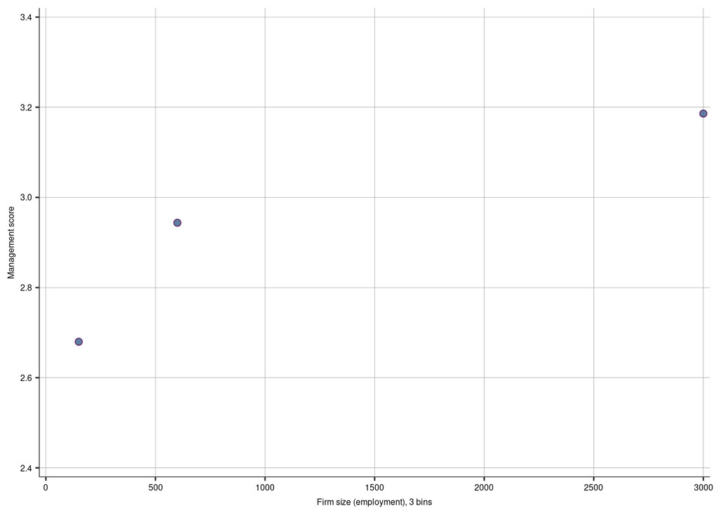

```r
# generating variables by mean (3 bins)
wms_mean03 <- wms  |>
  dplyr::group_by(emp3bins)  |>
  dplyr::summarize(management_emp3bins = mean(management))

# plotting conditional mean (3 bins of employment)
p1 <- ggplot(data = wms_mean03, aes(x = emp3bins, y = management_emp3bins)) +
  geom_point(size = 2, color = color[3], fill = color[1], shape = 21, alpha = 0.8, na.rm = T) +
  scale_y_continuous(expand = c(0.01, 0.01), limits = c(2.4, 3.4), breaks = seq(2.4, 3.4, by = 0.2)) +
  scale_x_continuous(expand = c(0.01, 0.01), limits = c(0, 3000), breaks = seq(0, 3000, by = 500)) +
  labs(x = "Firm size (employment), 3 bins", y = "Management score") +
  theme_bg()
p1
```

```r
# generating employment bins of 10
wms$emp10bins <- wms$emp_firm  |>  ggplot2::cut_number(10)

# summary
wms_summary <- wms  |>
  dplyr::select(emp_firm, emp10bins)  |>
  dplyr::group_by(emp10bins)  |>
  dplyr::summarise_all(tibble::lst(min, max, mean, median, sd, length))
wms_summary
```

```
## # A tibble: 10 × 7
##    emp10bins          min   max  mean median    sd length
##    <fct>            <dbl> <dbl> <dbl>  <dbl> <dbl>  <int>
##  1 [100,144]          100   140  119.    118  11.6     30
##  2 (144,180]          145   180  164.    160  12.9     40
##  3 (180,229]          184   228  204     200  10.2     20
##  4 (229,278]          230   275  251.    250  11.6     30
##  5 (278,353]          280   350  310.    300  23.1     30
##  6 (353,500]          356   500  432.    405  50.7     36
##  7 (500,670]          520   670  583.    600  49.3     25
##  8 (670,1.11e+03]     700  1100  906.    900 137.      29
##  9 (1.11e+03,2e+03]  1150  2000 1515.   1500 290.      34
## 10 (2e+03,5e+03]     2100  5000 3439.   3500 982.      26
```

```r
# re-coding
levels(wms$emp10bins) <- wms_summary  |>
  dplyr::pull(mean)  |>
  round()

wms$emp10bins <- as.numeric(levels(wms$emp10bins))[wms$emp10bins]

# summary
wms  |>
  dplyr::select(emp_firm, emp10bins)  |>
  dplyr::group_by(emp10bins)  |>
  dplyr::summarise_all(tibble::lst(min, max, mean, median, sd, length))
```

```
## # A tibble: 10 × 7
##    emp10bins   min   max  mean median    sd length
##        <dbl> <dbl> <dbl> <dbl>  <dbl> <dbl>  <int>
##  1       119   100   140  119.    118  11.6     30
##  2       164   145   180  164.    160  12.9     40
##  3       204   184   228  204     200  10.2     20
##  4       251   230   275  251.    250  11.6     30
##  5       310   280   350  310.    300  23.1     30
##  6       432   356   500  432.    405  50.7     36
##  7       583   520   670  583.    600  49.3     25
##  8       906   700  1100  906.    900 137.      29
##  9      1515  1150  2000 1515.   1500 290.      34
## 10      3439  2100  5000 3439.   3500 982.      26
```

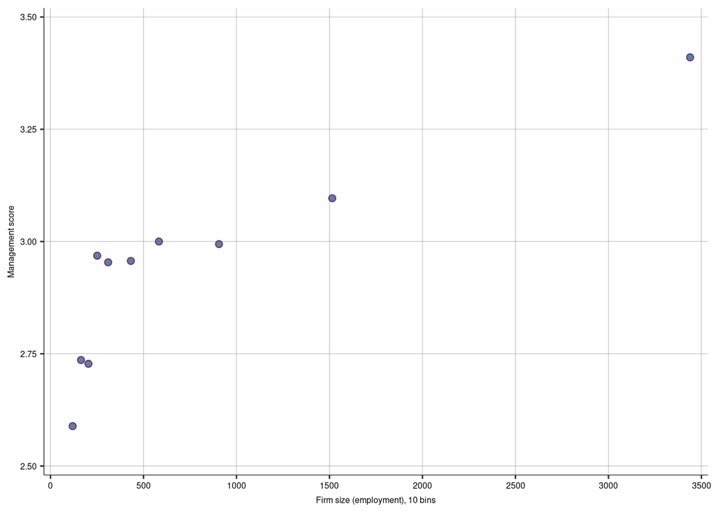

```r
# generating variables by mean (10 bins)
wms_mean10 <- wms  |>
  dplyr::group_by(emp10bins)  |>
  dplyr::summarize(management_emp10bins = mean(management))

# plotting conditional mean (10 bins of employment)
p2 <- ggplot(data = wms_mean10, aes(x = emp10bins, y = management_emp10bins)) +
  geom_point(size = 2, color = color[3], fill = color[1], shape = 21, alpha = 0.8, na.rm = T) +
  scale_y_continuous(expand = c(0.01, 0.01), limits = c(2.5, 3.5), breaks = seq(2.5, 3.5, by = 0.25)) +
  scale_x_continuous(expand = c(0.01, 0.01), limits = c(0, 3500), breaks = seq(0, 3500, by = 500)) +
  labs(x = "Firm size (employment), 10 bins", y = "Management score") +
  theme_bg()
p2
```

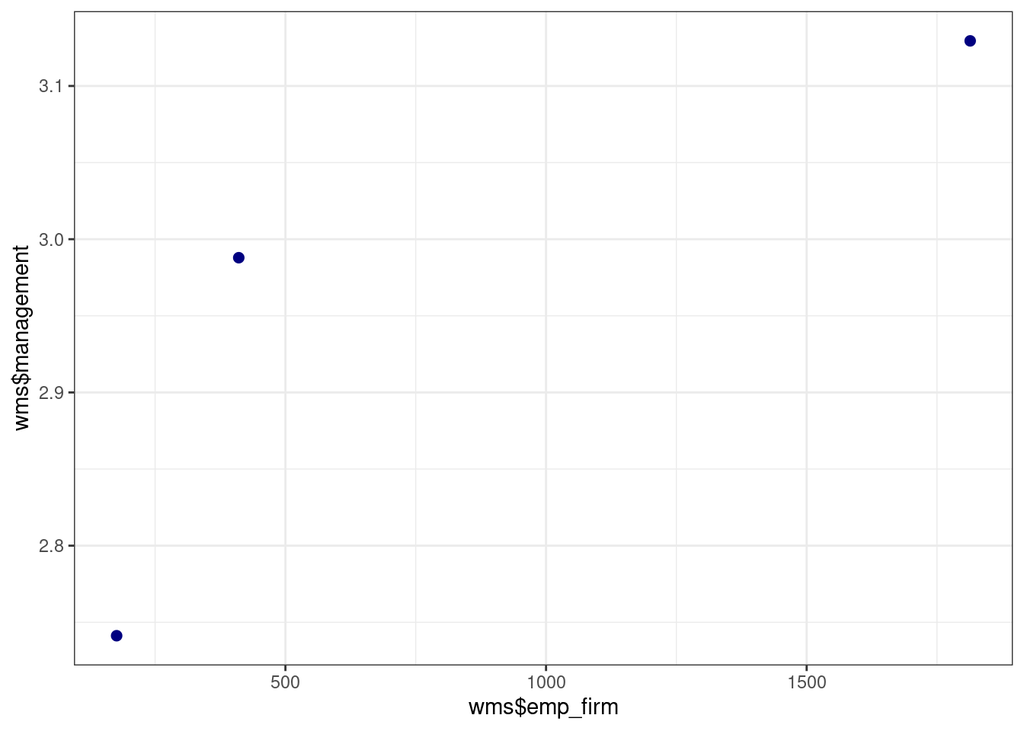

```
## Call: binsreg
##
## Binscatter Plot
## Bin selection method (binsmethod)  =  User-specified
## Placement (binspos)                =  Quantile-spaced
## Derivative (deriv)                 =  0
##
## Group (by)                         =  Full Sample
## Sample size (n)                    =  300
## # of distinct values (Ndist)       =  108
## # of clusters (Nclust)             =  NA
## dots, degree (p)                   =  0
## dots, smooth (s)                   =  0
## # of bins (nbins)                  =  3
```

```r
# this is a simpler solution, similar looking graph (not in book):
binsreg::binsreg(wms$management, wms$emp_firm, nbins = 3)
```

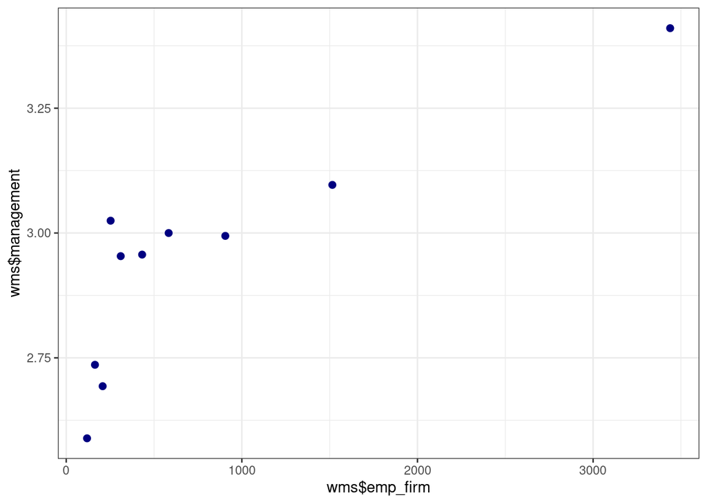

```
## Call: binsreg
##
## Binscatter Plot
## Bin selection method (binsmethod)  =  User-specified
## Placement (binspos)                =  Quantile-spaced
## Derivative (deriv)                 =  0
##
## Group (by)                         =  Full Sample
## Sample size (n)                    =  300
## # of distinct values (Ndist)       =  108
## # of clusters (Nclust)             =  NA
## dots, degree (p)                   =  0
## dots, smooth (s)                   =  0
## # of bins (nbins)                  =  10
```

```r
binsreg::binsreg(wms$management, wms$emp_firm, nbins = 10)
```

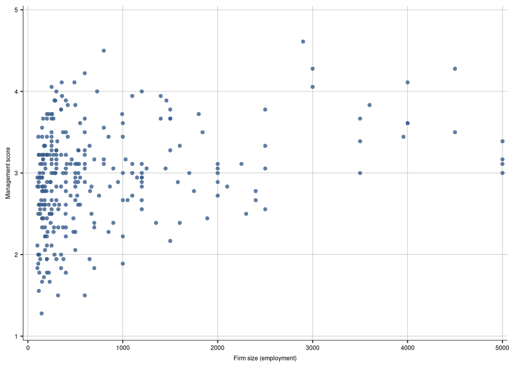

```r
# plotting avg score by employment
p3 <- ggplot(data = wms, aes(x = emp_firm, y = management)) +
  geom_point(color = color[1], size = 1.5, shape = 16, alpha = 0.8, show.legend = FALSE, na.rm = TRUE) +
  scale_x_continuous(expand = c(0.01, 0.01), limits = c(0, 5000), breaks = seq(0, 5000, by = 1000)) +
  scale_y_continuous(expand = c(0.01, 0.01), limits = c(1, 5), breaks = seq(1, 5, 1)) +
  labs(x = "Firm size (employment)", y = "Management score") +
  theme_bg()
p3
```

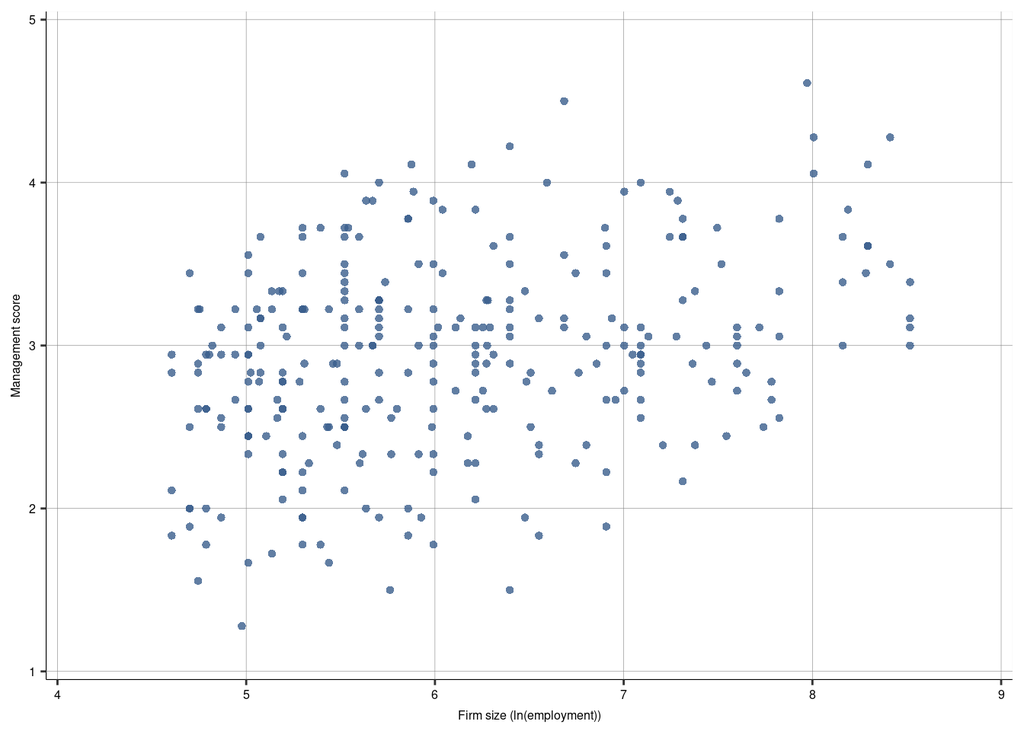

```r
# creating log var
wms$lnemp <-  log(wms$emp_firm)

# plotting avg score by employment (log)
p4 <- ggplot(data = wms, aes(x = lnemp, y = management)) +
  geom_point(color = color[1], size = 1.5, shape = 16, alpha = 0.8, show.legend = FALSE, na.rm = TRUE) +
  scale_x_continuous(expand = c(0.01, 0.01), limits = c(4, 9), breaks = seq(4, 9, by = 1)) +
  scale_y_continuous(expand = c(0.01, 0.01), limits = c(1, 5), breaks = seq(1, 5, 1)) +
  labs(x = "Firm size (ln(employment))", y = "Management score") +
  theme_bg()
p4
```

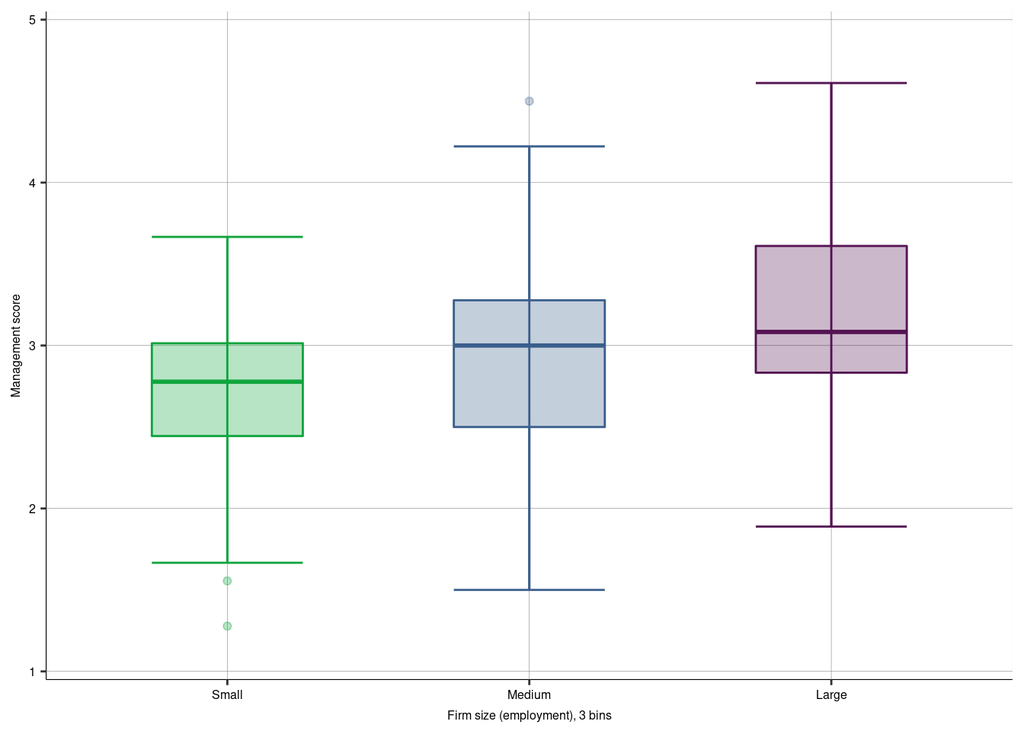

```r
# transforming as bin categories factor
wms$emp3bins <- as.factor(wms$emp3bins)
levels(wms$emp3bins) <- c("Small", "Medium", "Large")

# plotting boxplots
p5 <- ggplot(data = wms, aes(x = emp3bins, y = management)) +
  stat_boxplot(aes(group = emp3bins), geom = "errorbar", width = 0.5, color = c(color[2], color[1], color[3]), size = 0.5, na.rm = T) +
  geom_boxplot(aes(group = emp3bins), color = c(color[2], color[1], color[3]), fill = c(color[2], color[1], color[3]), size = 0.5, width = 0.5, alpha = 0.3, na.rm = T) +
  labs(x = "Firm size (employment), 3 bins", y = "Management score") +
  scale_y_continuous(expand = c(0.01, 0.01), limits = c(1, 5), breaks = seq(1, 5, 1)) +
  theme_bg()
p5
```

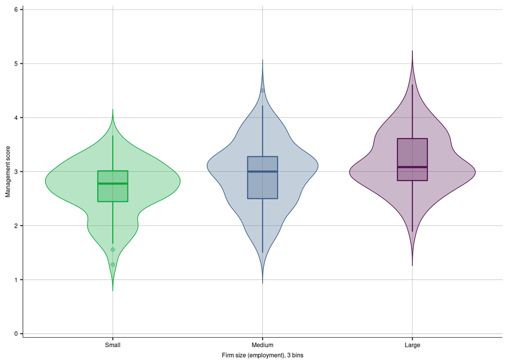

```r
# plotting violin plots
p6 <- ggplot(data = wms, aes(x = emp3bins, y = management, color = emp3bins, fill = emp3bins)) +
  geom_violin(aes(group = emp3bins), size = 0.3, alpha = 0.3, trim = F, show.legend = F, na.rm = TRUE) +
  geom_boxplot(aes(group = emp3bins), color = c(color[2], color[1], color[3]), fill = c(color[2], color[1], color[3]), size = 0.5, width = 0.2, alpha = 0.3, na.rm = T) +
  labs(x = "Firm size (employment), 3 bins", y = "Management score") +
  scale_y_continuous(expand = c(0.01, 0.01), limits = c(0, 6), breaks = seq(0, 6, 1)) +
  scale_color_manual(
    name = "",
    values = c(color[2], color[1], color[3])
  ) +
  scale_fill_manual(
    name = "",
    values = c(color[2], color[1], color[3])
  ) +
  theme_bg()
p6
```

### 5.1.4 Dependence, Covariance and Correlation

**Dependence of two variables**, also called **statistical dependence** means that the conditional distributions of one variable *(y)* are not the same when conditional on different values of the other variable *(x)*. In contrast, **independence of variables** means that the distribution of one conditional on the other is the same, regardless of the value of the conditioning variable. Dependence of *y* and *x* may take many forms, but the most important form of dependence is **mean-dependence**: the mean of *y* is different when the value of *x* is different.

The **covariance** and the **correlation coefficient** are measures of this mean-dependence. The two measures are very closely related: the correlation coefficient is the standardized version of the covariance.

The formula for the covariance between two variables *x* and *y* in a dataset with *n* observations is:
$$Cov[x, y] = \frac{\sum_i(x_i -\hat x)(y_i - \hat y)}{n}$$
The correlation coefficient divides this by the product of the two standard deviations:
$$Corr[x, y] = \frac{Cov[x, y]}{Std[x]Std[y]}$$
The covariance may be any positive or negative number, while the correlation coefficient is bound to be between -1 and 1. But their sign is always the same: the covariance is zero when the correlation coefficient is zero **(uncorrelated)**; the covariance is positive when the correlation coefficient is positive **(positively correlated)**; the covariance is negative when the correlation coefficient is negative **(negative correlated)**. The magnitude of the correlation coefficient shows the strength of the association: a correlation of 0.2 or less can be considered weak, and a correlation above 0.7 is usually considered strong. If two variables are independent, the covariance and the correlation coefficient are both zero.

### 5.1.5 From Laten Variables to Observed Variables

Often, the *y* or *x* variables we have in question are abstract concepts: the quality of management of a firm, skills of an employee, health of a person…Typically, such variables are not parts of an actual dataset, and they can’t be because they are too abstract. Such variables are called **latent variables**. Data analysis can help answer questions involving latent variables only by substituting observed variables for them. Those observed variables are called **proxy variables**.

Data analysis compares values of measured variables. Even if those variables are supposed to measure abstract concepts, it’s never the abstract concepts themselves that we have in our data. A specific issue arises when our data contains not one but more variables that could serve as proxies to the latent variable we want to examine. The question here is how to combine multiple observed variables:

- Use one of the observed variables
- Take the average (or sum) of the observed variables
- Use principal component analysis (PCA) to combine the observed variables

Using one measured variable and excluding the rest has the advantage of easy interpretation, and the disadvantage of discarding potentially useful information contained in the other variables.

Taking the average of all measured variables makes use of all information in a simple way. When all of those variables are measured using the same scale, this approach yields a combined measure with a natural interpretation. When the variables are measured at different scales, we need to bring the observed variables to the same scale, usually by standardizing them **(z-score)**. By taking a simple average of all these variables we give them equal weight. This may be a disadvantage if some of the variables are better measures of the latent variable than others.

**Principal component analysis (PCA)** is a method to give higher weights to the observable variables that are better measures. PCA finds those weights by examining how strongly they would be related with the weighted average.

```r
# CASE STUDY: Management quality and firm size: describing patterns of association
# calculating overall correlation coefficient
cor(wms$management, wms$emp_firm, use = "complete.obs")
```

```
## [1] 0.3019954
```

```r
# looking at the most recent industry code for the firms
table(wms$sic)
```

```
##
## 20 22 23 24 25 26 27 28 29 30 31 32 33 34 35 36 37 38 39
## 34 18 14  3 13 13  8 37  3 29  6 11 14 25 18 18 26  5  5
```

```r
# recoding industry codes
wms$industry_broad[wms$sic <= 21] <- "food_drinks_tobacco"
wms$industry_broad[wms$sic >= 22 & wms$sic <= 23 | wms$sic == 31] <- "textile_apparel_leather_etc"
wms$industry_broad[wms$sic >= 24 & wms$sic <= 27] <- "wood_furniture_paper"
wms$industry_broad[wms$sic >= 28 & wms$sic <= 30] <- "chemicals_etc"
wms$industry_broad[wms$sic >= 32 & wms$sic < 35] <- "materials_metals"
wms$industry_broad[wms$sic >= 35 & wms$sic < 37] <- "electronics"
wms$industry_broad[wms$sic == 37] <- "auto"
wms$industry_broad[wms$sic >= 38] <- "other"

table(wms$industry_broad)
```

```
##
##                        auto               chemicals_etc
##                          26                          69
##                 electronics         food_drinks_tobacco
##                          36                          34
##            materials_metals                       other
##                          50                          10
## textile_apparel_leather_etc        wood_furniture_paper
##                          38                          37
```

```r
# summary management
wms  |>
  dplyr::select(management, industry_broad)  |>
  dplyr::filter(!is.na(industry_broad))  |>
  dplyr::group_by(industry_broad)  |>
  dplyr::summarise(
    Min = min(management),
    Max = max(management),
    SD = sd(management),
    Median = median(management),
    n()
  )
```

```
## # A tibble: 8 × 6
##   industry_broad                Min   Max    SD Median `n()`
##   <chr>                       <dbl> <dbl> <dbl>  <dbl> <int>
## 1 auto                         2.28  4.28 0.553   3.19    26
## 2 chemicals_etc                1.28  4.11 0.550   3       69
## 3 electronics                  1.5   4.5  0.693   3.11    36
## 4 food_drinks_tobacco          1.89  4.22 0.526   2.83    34
## 5 materials_metals             1.56  4.28 0.565   2.86    50
## 6 other                        1.78  4.61 0.844   3.56    10
## 7 textile_apparel_leather_etc  1.78  4    0.567   2.78    38
## 8 wood_furniture_paper         1.72  3.56 0.556   2.83    37
```

```r
# summary employment
wms  |>
  dplyr::select(emp_firm, industry_broad)  |>
  dplyr::filter(!is.na(industry_broad))  |>
  dplyr::group_by(industry_broad)  |>
  dplyr::summarise(
    Min = min(emp_firm),
    Max = max(emp_firm),
    SD = sd(emp_firm),
    Median = median(emp_firm),
    n()
  )
```

```
## # A tibble: 8 × 6
##   industry_broad                Min   Max    SD Median `n()`
##   <chr>                       <dbl> <dbl> <dbl>  <dbl> <int>
## 1 auto                          130  5000 1625.    500    26
## 2 chemicals_etc                 116  2000  466.    356    69
## 3 electronics                   115  5000 1127.    295    36
## 4 food_drinks_tobacco           120  2400  666.    471    34
## 5 materials_metals              100  5000 1151.    335    50
## 6 other                         200  2900  867.    350    10
## 7 textile_apparel_leather_etc   110  4000  899.    350    38
## 8 wood_furniture_paper          100  3500  856.    300    37
```

```r
# calculating correlation per industry broad
cor <- wms  |>
  dplyr::group_by(industry_broad)  |>
  dplyr::summarize(COR = cor(management, emp_firm))

# creating a table with the average of all relevant variables for the latent
wms_tab <- wms  |>
  dplyr::select(emp_firm, industry_broad, management)  |>
  dplyr::group_by(industry_broad)  |>
  dplyr::summarise(Mean = mean(management), Obs = n())

# adding correlation to the table
wms_tab$cor <- cor$COR

# recoding variables
wms_tab$industry_broad <- wms_tab$industry_broad  |>  dplyr::recode(
  auto = "Auto",
  chemicals_etc = "Chemicals",
  electronics = "Machinery, equipment, electronics",
  food_drinks_tobacco = "Food, drinks, tobacco",
  materials_metals = "Materials, metals",
  textile_apparel_leather_etc = "Textile, apparel, leather",
  wood_furniture_paper = "Wood, furniture, paper",
  other = "Other"
)

# adding the last row with all category
last_row <- wms_tab  |>  dplyr::summarise(Mean = mean(Mean), Obs = sum(Obs), cor = mean(cor))
last_row$industry_broad <- "All"

wms_tab <- wms_tab  |>  dplyr::add_row(
  industry_broad = last_row$industry_broad,
  Mean = last_row$Mean,
  cor = last_row$cor,
  Obs = last_row$Obs
)

# formatting the table
wms_tab <- wms_tab  |>  dplyr::select(industry_broad, cor, Mean, Obs)
wms_tab
```

```
## # A tibble: 9 × 4
##   industry_broad                       cor  Mean   Obs
##   <chr>                              <dbl> <dbl> <int>
## 1 Auto                              0.502   3.25    26
## 2 Chemicals                         0.0534  2.97    69
## 3 Machinery, equipment, electronics 0.282   3.15    36
## 4 Food, drinks, tobacco             0.0521  2.87    34
## 5 Materials, metals                 0.321   2.85    50
## 6 Other                             0.628   3.29    10
## 7 Textile, apparel, leather         0.361   2.77    38
## 8 Wood, furniture, paper            0.295   2.72    37
## 9 All                               0.312   2.98   300
```

# 6 CHAPTER 05: Generalization from Data (inference)

The act of generalization is called **inference**: we infer something from our data about a more general phenomenon because we want to use that knowledge in some other situation. Inference is best broken down into two steps: *generalizing from the data to the general pattern it represents*, and *generalizing from that general pattern to the general pattern that is behind the situation we truly care about*.

The first step is **statistical inference**, which aims at generalizing to the situation that our data represents, using statistical methods. The simplest case is a random sample that represents a well-defined **population**. The **general pattern** is a more abstract concept. For our data to represent this general pattern, it is not necessary that all variables have the same distribution. Instead, we require that the specific pattern is the same. Generalizing to a general pattern that our data represents can make sense even when our data covers an entire population.

The second step is assessing the **external validity** of the results. External validity is about whether the general pattern our data represents is the same as the general pattern that would be relevant for the situation we truly care about. If the general pattern behind the situation we care about and the data we have is the same, what we uncover from our data has high external validity for the situation we care about. If, on the other hand, the general pattern behind the situation we care about is different from the general pattern that our data represents, whatever we uncover from our data would have low external validity. External validity is best thought of as a continuum, from very high (our data represents the same general pattern we are interested in) through medium (the two general patterns are similar but not the same) to very low (the two general patterns are very different).

Assessing external validity cannot be done with statistical methods. In practice, the goal of most analyses is a quantitative summary of patterns: a **statistic**. We want to infer the **true value** of the statistic after having computed its **estimated value** from the actual data. The true value is the value in a population or a general pattern. Thus, external validity is about the extent to which the true value of the statistic is similar in the general pattern our data represents and the general pattern that’s behind the situation we care about. The goal of statistical inference is to uncover the true value of the statistic in the general pattern, or population, that our data represents. The starting point of statistical inference is the estimated value of the statistic that we calculate from our data. It is called an estimated value because the reason for calculating it is to uncover (estimate) the true value.

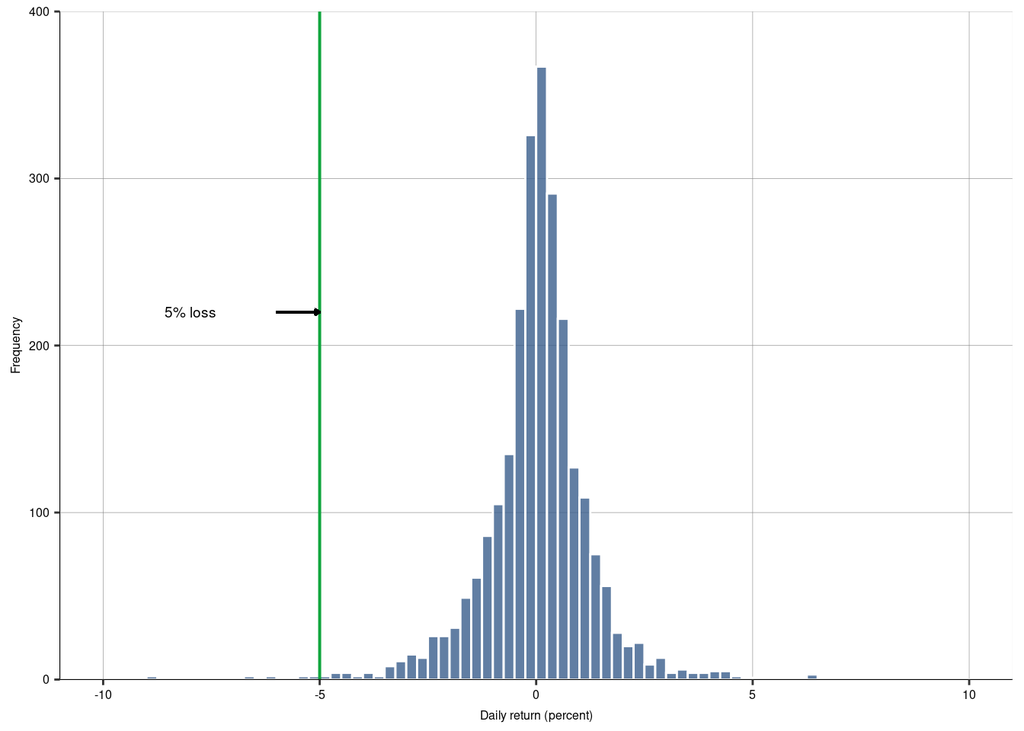

```r
# CASE STUDY: What likelihood of loss to expect on a stock portfolio
# load data
sp500 <- read_csv("input/SP500_2006_16_data.csv", na = c("", "#N/A"))
# subsetting all the values that are NOT NAs
sp500 <- subset(sp500, VALUE != "NA")

# creating percent return
sp500 <- sp500 |>
  dplyr::mutate(pct_return = (VALUE - dplyr::lag(VALUE)) / dplyr::lag(VALUE) * 100)

# creating date variable
sp500$year <- format(sp500$DATE, "%Y")
sp500$month <- format(sp500$DATE, "%m")
sp500$year <- as.numeric(sp500$year)
sp500$month <- as.numeric(sp500$month)
sp500$yearmonth <- sp500$year * 100 + sp500$month

# plotting daily returns
p1 <- ggplot(sp500, aes(pct_return)) +
  geom_histogram_da(binwidth = 0.25, type = "frequency") +
  geom_vline(xintercept = -5, size = 0.7, color = color[2]) +
  labs(x = "Daily return (percent)", y = "Frequency") +
  coord_cartesian(xlim = c(-10, 10), ylim = c(0, 400)) +
  scale_y_continuous(expand = c(0, 0)) +
  geom_segment(aes(x = -6, y = 220, xend = -5, yend = 220), arrow = arrow(length = unit(0.1, "cm"))) +
  annotate("text", x = -8, y = 220, label = "5% loss", size = 2.5) +
  theme_bg()
p1
```

## 6.1 Repeated Samples, Sampling Distribution and Standard Error (SE)

The conceptual background to statistical inference is **repeated samples**. The basic idea is that the data we observe is one example of many data sets that could have been observed. Each of those potentially observed data sets can be viewed as a sample drawn from the population, or the more abstract general pattern.

The goal of statistical inference is learning the value of a statistic in the population, or general pattern, represented by our data. With repeated samples, the statistic has a distribution: its value may differ from sample to sample. Within each sample the calculated value of statistic is called an **estimate** of the statistic. The distribution of the statistic is called its **sampling distribution**. The sampling distribution of a statistic shows the values that the estimated statistic takes across repeated samples. The most important aspect of this sampling distribution is its standard deviation: how much spread there is across repeated samples. The standard deviation of the sampling distribution has a specific name: the **standard error (SE)** of the statistic ($se(\bar X) = \frac{\sigma}{\sqrt N}$)

The sampling distribution has three important properties:

1. The average of the values in repeated samples is approximately equal to its true value (the value of the entire population, or general pattern, represented by our data.) -> **unbiasedness**
2. The sampling distribution is approximately normal. -> **approximate normality**
3. The standard error is smaller the larger the sample, with a proportionally factor of the square root of the sample size. -> **root-n convergence**

Because the sampling distribution is approximately normal, we know that the measured values fall within plus or minus two standard errors (SE) of the truth approximately 95% of the time. Similarly, we know that they fall within plus or minus 1.6 SE of the truth with a 90% chance, and within 2.6 SE with a 99% chance.

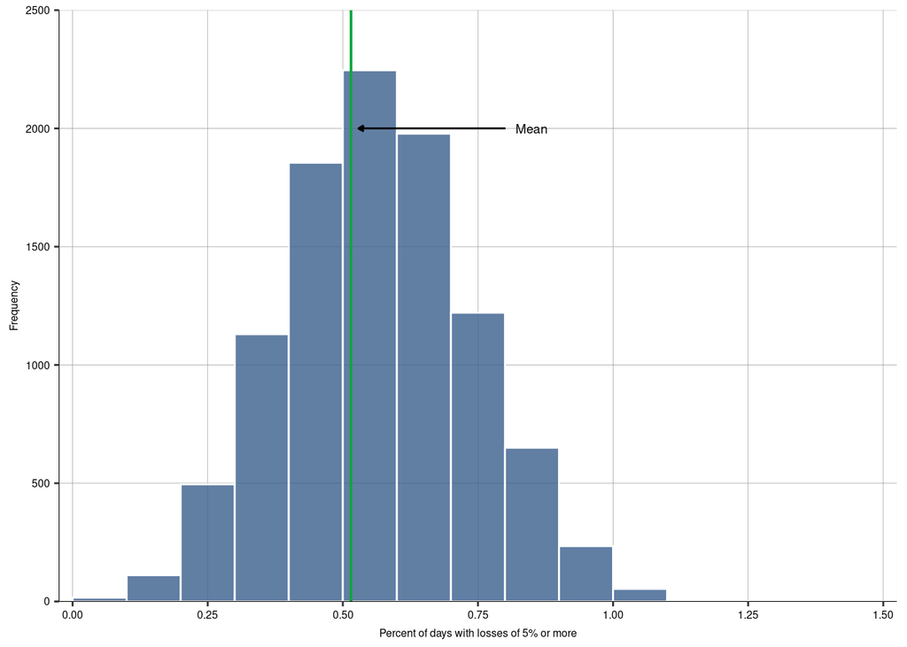

```r
# CASE STUDY: What Likelihood of Loss to Expect on a Stock Portfolio?
# Create 10 000 samples, with 500 and 1000 observations in each sample, taken from sp500
# remove first row as it has NA in pct_return
pct_return <- sp500  |>
  dplyr::filter(!is.na(pct_return))  |>
  dplyr::pull(pct_return)

# function for a specified number of samples: draws a specified number of observations from a vector, calculates the percentage of obs with greater than 5% losses
# 3 inputs: 'vector' is a vector of the source data, in this case pct_return. 'n_samples' is the number of samples we want to use.
# 'n_obs' is the number of observations in each sample
# output is a vector
create_samples <- function(vector, n_samples, n_obs) {
  samples_pcloss <- c()
  for (i in 1:n_samples) {
    single_sample <- sample(vector, n_obs, replace = FALSE)
    samples_pcloss[i] <- sum(single_sample < -5) / n_obs * 100
  }
  samples_pcloss
}

set.seed(123)

# creating samples
nobs_1000 <- create_samples(pct_return, 10000, 1000)
nobs_500 <- create_samples(pct_return, 10000, 500)

# converting results as tibble
nobs_df <- tibble(nobs_500,nobs_1000)

# calculating the se
se <- qnorm(0.95) * sd(nobs_df$nobs_1000) / sqrt(length(nobs_df$nobs_1000))

# calculating CI
left <- mean(nobs_df$nobs_1000) - se
right <- mean(nobs_df$nobs_1000) + se

# plotting simulated number of days with big losses
options(digits = 2)

p2 <- ggplot(nobs_df, aes(nobs_1000)) +
  geom_histogram(binwidth = 0.1, color = color.outline, fill = color[1], alpha = 0.8, boundary = 0, closed = "left") +
  labs(x = "Percent of days with losses of 5% or more", y = "Frequency") +
  geom_vline(aes(xintercept = mean(nobs_1000)), color = color[2], size = 0.7) +
  coord_cartesian(xlim = c(0, 1.5), ylim = c(0, 2500)) +
  scale_x_continuous(expand = c(0.01, 0.01), limits = c(0, 1.5), breaks = seq(0, 1.5, by = 0.25)) +
  scale_y_continuous(expand = c(0.00, 0.00), limits = c(0, 2500), breaks = seq(0, 2500, by = 500)) +
  geom_segment(aes(x = 0.8, y = 2000, xend = 0.53, yend = 2000), arrow = arrow(length = unit(0.1, "cm"))) +
  annotate("text", x = 0.85, y = 2000, label = "Mean", size = 2.5) +
  theme_bg()
p2
```

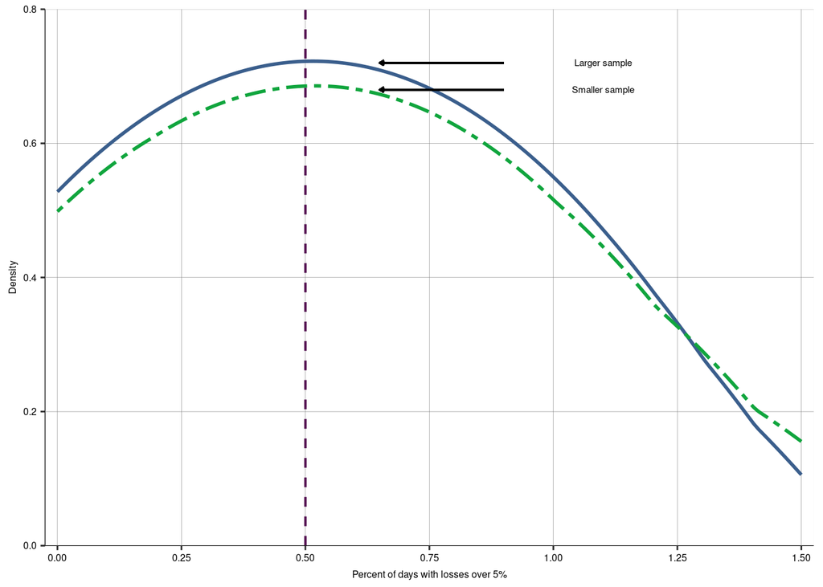

```r
# comparing density for both simulations
p3 <- ggplot(nobs_df, aes(nobs_1000)) +
  stat_density(geom = "line", aes(color = "n1000"), bw = 0.45, size = 1, kernel = "epanechnikov") +
  stat_density(geom = "line", aes(nobs_500, color = "n500"), bw = 0.45, linetype = "twodash", size = 1, kernel = "epanechnikov") +
  labs(x = "Percent of days with losses over 5%", y = "Density") +
  geom_vline(xintercept = 0.5, colour = color[3], size = 0.7, linetype = "dashed") +
  geom_segment(aes(x = 0.9, y = 0.72, xend = 0.65, yend = 0.72), size = 0.5, arrow = arrow(length = unit(0.1, "cm"))) +
  annotate("text", x = 1.1, y = 0.72, label = "Larger sample", size = 2) +
  geom_segment(aes(x = 0.9, y = 0.68, xend = 0.65, yend = 0.68), size = 0.5, arrow = arrow(length = unit(0.1, "cm"))) +
  annotate("text", x = 1.1, y = 0.68, label = "Smaller sample", size = 2) +
  scale_x_continuous(expand = c(0.01, 0.01), limits = c(0, 1.5), breaks = seq(0, 1.5, by = 0.25)) +
  scale_y_continuous(expand = c(0.00, 0.00), limits = c(0, 0.8), breaks = seq(0, 0.8, by = 0.2)) +
  scale_color_manual(name = "", values = c(n1000 = color[1], n500 = color[2])) +
  theme_bg() +
  theme(legend.position = "none")
p3
```

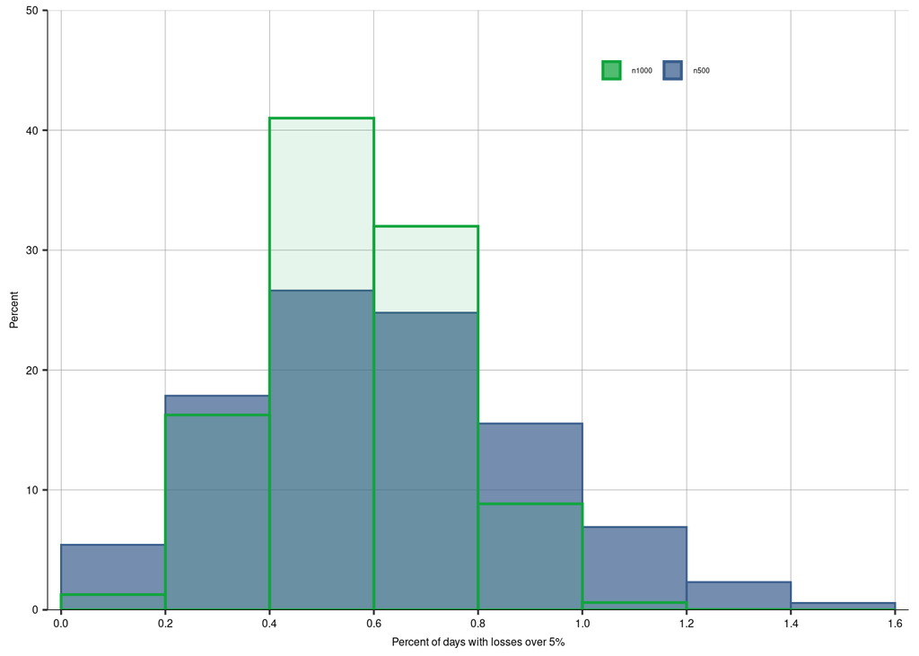

```r
# plotting histogram of big loss simulations with N = 500 and N = 1000
p4 <- ggplot(data = nobs_df) +
  geom_histogram(aes(x = nobs_500, y = (..count..) / sum(..count..) * 100, color = "n500", fill = "n500"), binwidth = 0.2, boundary = 0, closed = "left", alpha = 0.7) +
  geom_histogram(aes(x = nobs_1000, y = (..count..) / sum(..count..) * 100, color = "n1000", fill = "n1000"), binwidth = 0.2, boundary = 0, closed = "left", alpha = 0.1, size = 0.7) +
  ylab("Percent") +
  xlab("Percent of days with losses over 5%") +
  scale_x_continuous(expand = c(0.01, 0.01), limits = c(0, 1.6), breaks = seq(0, 1.6, by = 0.2)) +
  scale_y_continuous(expand = c(0.00, 0.00), limits = c(0, 50)) +
  scale_color_manual(name = "", values = c(color[2], color[1])) +
  scale_fill_manual(name = "", values = c(color[2], color[1])) +
  theme_bg() +
  theme(
    legend.position = c(0.7, 0.9),
    legend.key.size = unit(x = 0.4, units = "cm"),
    legend.direction = "horizontal"
  )
p4
```

```r
# looking at distribution in a table
janitor::tabyl(nobs_df$nobs_500, sort = TRUE)
```

```
##  nobs_df$nobs_500    n percent
##               0.0  542  0.0542
##               0.2 1785  0.1785
##               0.4 2662  0.2662
##               0.6 2477  0.2477
##               0.8 1553  0.1553
##               1.0  690  0.0690
##               1.2  231  0.0231
##               1.4   51  0.0051
##               1.6    6  0.0006
##               1.8    3  0.0003
```

```r
janitor::tabyl(nobs_df$nobs_1000, sort = TRUE)
```

```
##  nobs_df$nobs_1000    n percent
##                0.0   16  0.0016
##                0.1  111  0.0111
##                0.2  495  0.0495
##                0.3 1130  0.1130
##                0.4 1855  0.1855
##                0.5 2246  0.2246
##                0.6 1978  0.1978
##                0.7 1221  0.1221
##                0.8  650  0.0650
##                0.9  234  0.0234
##                1.0   53  0.0053
##                1.1    8  0.0008
##                1.2    2  0.0002
##                1.3    1  0.0001
```

## 6.2 The Confidence Interval

The **confidence interval (CI)** is the most important measure of statistical inference. The idea of the CI is to give us a range, in which we can expect the true value to lie with a certain probability. That probability is something data analysts need to pick. Typical probability picks are 95% or 90%.

The confidence interval is constructed as a symmetric range around the estimated value of the statistic in our data. We first calculate the estimated value of the statistic in our data. Then we specify the length of the CI on the two sides of the estimated value. We use the SE to know the length of the appropriate CI. The SE is the general unit of measurement when constructing confidence intervals. The appropriate 95% CI is the $\pm2$ SE or, more precisely, 1.96 SE interval around the estimate from the data. The appropriate 90% CI is the $\pm1.6$ SE interval around the estimate from the data; and the appropriate 99% CI is the $\pm2.6$ SE interval around it.

## 6.3 Estimating the Standard Error with the Bootstrap Method

The **bootstrap** is a method that creates the sampling distribution across repeated samples that are representative of the same population, or general pattern, as the original data and also have the same size. The bootstrap method takes the original data and draws many repeated samples of the size of that data. The trick is that the samples are drawn with replacement. The observations are drawn randomly one by one from the original data; once an observation is drawn it is “replaced” into the pool so that it can be drawn again, with the same probability as any other observation. The drawing stops when the sample reaches the size of the original data. The result is a sample of the same size as the original data, yielding a single **bootstrap sample**. This bootstrap sample includes some of the original observations multiple times, and it does not include some of the other original observations. The distribution of a statistic across these repeated bootstrap samples is a good approximation to the sampling distribution that would look like across samples similar to the original data.

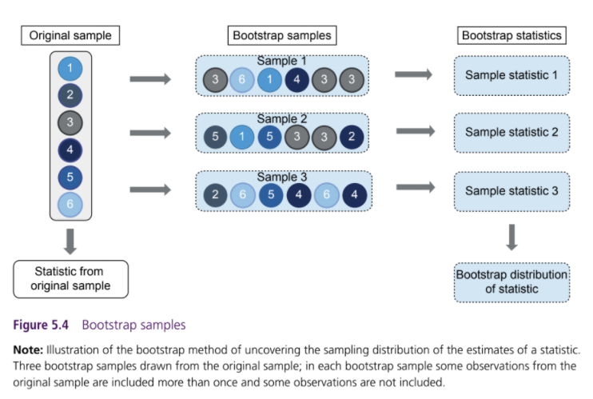

The bootstrap method works if the variable we consider is independent across observations. By sampling observations one by one and then replacing them into the pool to be possibly drawn again, we destroy the before-after relationships in the original data. That is not a problem if there is no relationship across observations, which is true in most cross-sectional data.

Since the distribution of a statistic across bootstrap samples is a good approximation of the sampling distribution, it gives a good approximation of the standard error, too. The **bootstrap estimate of the standard error** is the standard deviation of the estimated values of the statistic across the bootstrap samples. Once we have the standard error, we have everything we need for constructing the confidence interval of our choice.

The bootstrap method have its limitations, on top of the independence, it tends to provide very poor standard error estimates in the presence of extreme values. Moreover, it may produce poor standard error estimates in small samples if the statistic is not the mean but the median or some other quantile.

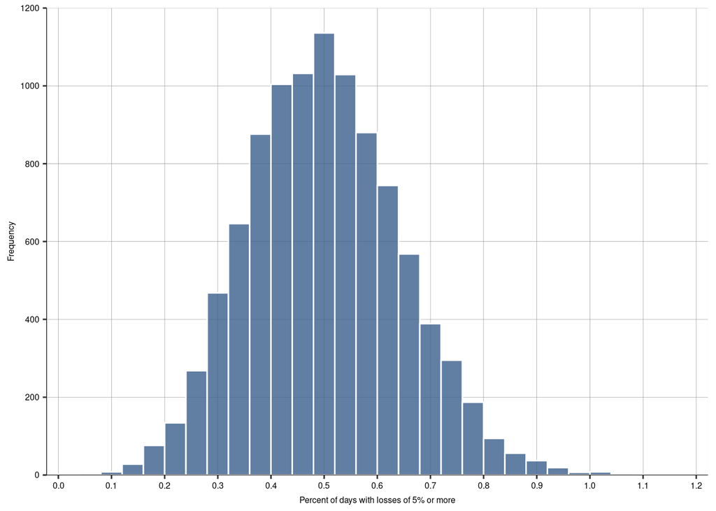

```r
# CASE STUDY: What Likelihood of Loss to Expect on a Stock Portfolio?
set.seed(573164)

M <- 10000

Results <- matrix(rep(0, (M * 10)), nrow = M, ncol = 10)

for (i in 1:M) {
  bsample <- sample(sp500$pct_return, size = dim(sp500)[1], replace = TRUE)

  for (j in 1:10) {
    loss <- as.numeric(bsample < (-j)) * 100
    Results[i, j] <- mean(loss, na.rm = T)
  }
}

Results <- as_tibble(Results)
names(Results) <- c(
  "loss1", "loss2", "loss3", "loss4", "loss5", "loss6",
  "loss7", "loss8", "loss9", "loss10"
)

p1 <- ggplot(Results, aes(loss5)) +
  geom_histogram_da(type = "frequency", binwidth = 0.04, boundary = 0, closed = "left") +
  scale_y_continuous(expand = c(0, 0), limits = c(0, 1200), breaks = seq(0, 1200, 200)) +
  scale_x_continuous(expand = c(0.01, 0.01), limits = c(0, 1.2), breaks = seq(0, 1.2, 0.1)) +
  labs(x = "Percent of days with losses of 5% or more", y = "Frequency") +
  theme_bg()
p1
```

## The Standard Error Formula

There is a relatively simple formula for the standard error (SE) of the average ($\bar x$). The formula includes the root-n factor and just one another element. $\bar x$ is the estimate of the true mean value of *x* in the general pattern (or the population).

The **standard error formula** for $\bar x$ is
$$SE(\bar x) = \frac{1}{\sqrt n} Std[x]$$
where $Std[x]$ is the standard deviation of the variable in the data, and *n* is the number of observations in the data. The standard error is larger, the smaller the sample and the larger the standard deviation of the variable.

```r
# CASE STUDY: What Likelihood of Loss to Expect on a Stock Portfolio?
# using the psych package to figure out the sd = 0.07
psych::describe(sp500$pct_return > -5)
```

```
##    vars    n mean   sd median trimmed mad min max range skew kurtosis se
## X1    1 2518 0.99 0.07      1       1   0   0   1     1  -14      189  0
```

```r
# calculating the denominator of the SEM formula = 0.02
x <- sqrt((1 / 2519))

# calculating the product of both operations -> 0.02 * 0.07 = 0.0014 (0.14%) or the standard error of the mean
sem <- x * 0.07
sem
```

```
## [1] 0.0014
```

```r
# calculating the 95% CI
right <- 0.5 + 2 * 0.14
left <- 0.5 - 2 * 0.14
c(left, right)
```

```
## [1] 0.22 0.78
```

## 6.4 External Validity

The confidence interval summarizes uncertainty about the true value of the statistics in the population, or the general pattern, that our data represents. An important part in inference is defining the population, or general pattern, we care about (the future), and assessing how close it is to the population, or general pattern, our data represents (the past). **External validity** is the concept that captures the similarity of those two general patterns.

With *high* external validity, the confidence interval captures all uncertainty about our estimate. With *low* external validity, it does not. To assess external validity we need substantive knowledge of the situation. The most important challenges to external validity may be collected in three groups: **time**, **space**, and **sub-groups**.

First, *stability in time*. The data we analyze is always from the past, whereas the situation we care about is almost always in the future. Thus, in order to generalize from the data, we need to assume that the general pattern that was relevant in the past will remain relevant for the future. A specific issue with time is the occurrence of extreme values. Our data may be free of extreme values because some very rare extreme events may not have happened in the historic period that our data represents. However, this does not imply that such a rare extreme event could not happen in the future we care about.

Second, *stability through space*. The data we analyze may come from a different country, region, or city than the situation we care about.

Third, *stability across subgroups*. A pattern may be strong among one group of people, but it may not be there for people in different professional, age, gender, cultural, or income groups.